# Project 1: Predicting Heart Failure Readmission Rates Using CMS Hospital Quality Data

Merrimack College DSE6630: Healthcare & Life Sciences Analytics

Peter Gyorda

25 May 2026

# 1 Introduction

Hospital readmissions remain an important indicator of healthcare quality, patient outcomes, and hospital performance. Heart failure (HF) is one of the most common causes of hospitalization among Medicare beneficiaries and is associated with substantial rates of readmission. Understanding which hospital characteristics are associated with higher or lower readmission rates may help healthcare organizations identify opportunities for quality improvement and better patient outcomes.

This project uses publicly available Centers for Medicare & Medicaid Services (CMS) hospital quality datasets to investigate factors associated with heart failure readmissions. Multiple CMS data sources were integrated into a single analytic dataset containing measures of patient safety, hospital-acquired infections, spending, timely and effective care, outpatient imaging efficiency, patient experience (HCAHPS), and readmission outcomes.

The objective of this analysis is to determine whether hospital quality, safety, patient experience, and operational measures can be used to predict observed heart failure readmission rates. The final dataset contains 2,305 hospitals and 39 variables and will be used to perform exploratory analysis, feature selection, dimensionality reduction, clustering, and predictive modeling.

## 1.1 Our Analysis Plan

Our goal is to develop a predictive model that can help identify hospital characteristics associated with heart failure readmission rates. To maximize the likelihood of producing a useful and interpretable model, this analysis follows the major stages of the data science lifecycle, including data cleaning, exploratory data analysis, feature selection, data preprocessing, unsupervised learning, and supervised predictive modeling.

The analysis consists of two primary components. First, we will perform a segmentation (clustering) analysis to identify groups of hospitals with similar quality, safety, spending, operational, and patient-experience characteristics. This analysis will use a combination of Principal Component Analysis (PCA) and k-means clustering to reduce dimensionality and identify meaningful hospital segments.

Second, we will develop a supervised predictive model to estimate hospital heart failure readmission rates. An elastic net regression approach will be used because it combines regularization and variable selection, allowing us to identify the hospital characteristics most strongly associated with readmission outcomes while also producing a model capable of generating future predictions. Together, these analyses provide both descriptive insights into hospital performance patterns and predictive tools that may support quality-improvement efforts.

#### ADVENTURE 1 CHOSEN

For this project, Adventure 1 was selected. Rather than analyzing pneumonia-related readmissions, this analysis focuses on heart failure (HF) readmissions. Heart failure is a common and costly condition associated with frequent hospital readmissions, making it an important target for quality improvement efforts. The same analytical framework used in the original project was applied to heart failure data, including data preparation, exploratory analysis, principal component analysis (PCA), k-means clustering, and elastic net regression. This approach allows for direct comparison of methods while investigating a clinically distinct patient population.

## 1.3 A Fork in the Road!

Adventure 1 was selected for this project. The analysis focuses on heart failure (HF) readmissions using a cleaned and prepared dataset derived from multiple CMS hospital quality data sources. The final analytical dataset is loaded below and serves as the foundation for all subsequent exploratory, clustering, and predictive modeling analyses.

```r
## Comment out if this is NOT your choice:
HF_Ready <- read.csv(
  "HF_Ready_Updated.csv",
  stringsAsFactors = FALSE,
  check.names = FALSE
)
dat2Analyze <- HF_Ready
```

#### **Question 1**: [1 point]

Which dataset do you choose and why?

> I selected Adventure 1 and used the prepared heart failure dataset (HF_Ready.csv) generated during the data preparation phase. This dataset contains 2,305 hospitals and 39 variables and includes the preprocessing and feature engineering necessary for exploratory analysis, clustering, and predictive modeling. Using the prepared dataset allows the analysis to focus on understanding hospital factors associated with heart failure readmission rates while maintaining consistency with the analytical framework established in the original project.

## 1.4 Helper code: Using `R` like an object-oriented language

Categorical variables requiring ordinal encoding were processed during the data preparation stage when the HF_Ready dataset was created. Variables such as hospital infection performance, heart failure mortality performance, and hospital return days were converted from ordered categorical descriptions into numeric values suitable for machine learning analyses. Because the encoding was completed during data preparation, no additional ordinal encoding is required at this stage of the analysis.

# 2 Exploratory Data Analysis: Which of the possible target (outcome) variables should we use? (Continued)

**NOTE**: What follows is my (long-winded) answer to **Question 19** from the Demo.

### 2.1 Overview of our options

Before developing predictive models, it is important to determine which readmission measure best represents hospital performance for heart failure patients. Several related measures are available within the CMS readmission data, including:

Observed Readmission Rate Predicted Readmission Rate Expected Readmission Rate Excess Readmission Ratio Hospital Return Days for Heart Failure Patients

Each measure captures a slightly different aspect of hospital performance and patient outcomes. Therefore, understanding the meaning of each metric is essential before selecting the final outcome variable for modeling.

The variable Hospital Return Days for Heart Failure Patients provides valuable information regarding hospital performance relative to national benchmarks. Hospitals with fewer return days than average may indicate more effective discharge planning, follow-up care, and overall management of heart failure patients. Conversely, hospitals with more return days than average may reflect greater patient complexity, less effective transitions of care, or other factors associated with readmission risk.

Although this measure provides important context regarding hospital quality, it is best considered as a potential predictor rather than the primary outcome variable. The primary objective of this analysis is to understand and predict heart failure readmission performance. Therefore, the focus will remain on selecting the most appropriate readmission-rate measure from the available CMS metrics.

The following analyses compare the observed, predicted, and expected readmission rates, along with the Excess Readmission Ratio, to determine which outcome variable is most appropriate for subsequent modeling.

Table 1. Candidate outcome variables available for the heart failure readmission analysis.

| Possible Target | Description |
| --- | --- |
| `Hospital return days for heart failure patients` | Measures whether heart failure patients spend fewer, average, or more days in the hospital following readmission relative to national benchmarks. This variable provides useful context regarding hospit… |
| ExpectedReadmissionRate | The expected heart failure readmission rate after adjusting for patient characteristics and risk factors. This measure represents the readmission rate that would be anticipated for a hospital given it… |
| PredictedReadmissionRate | The estimated heart failure readmission rate predicted by the CMS risk-adjustment model. This metric reflects hospital performance after accounting for patient-level factors. |
| ExcessReadmissionRatio | The ratio of the predicted readmission rate to the expected readmission rate. Values greater than one indicate more readmissions than expected, while values less than one indicate fewer readmissions t… |
| observed_readmission_rate | The observed proportion of heart failure readmissions calculated as the number of readmissions divided by the number of eligible discharges. This represents the actual readmission experience observed … |

### 2.2 Summary statistics of the possible targets

Before selecting the final outcome variable for predictive modeling, it is helpful to examine the distribution and characteristics of each candidate measure. Summary statistics provide insight into the variability, central tendency, and overall behavior of the available heart failure readmission metrics and help identify which variables are most appropriate for modeling.

When evaluating potential outcome variables, particular attention will be given to interpretability, clinical relevance, and suitability for predictive analysis. Measures that directly reflect hospital performance with respect to heart failure readmissions are generally preferred because they provide a clearer connection between hospital characteristics and patient outcomes. In addition, variables with sufficient variation and complete data are more likely to produce meaningful predictive models.

The following summary table presents descriptive statistics for each candidate outcome variable and serves as the basis for selecting the final target variable for the remainder of the analysis.

**Table 2. Summary statistics for candidate heart failure outcome variables**

| **Characteristic** | **N = 2,305**<sup>1</sup> |
| --- | --- |
| Hospital Return Days |  |
| Better than average | 187 / 2,305 (8.1%) |
| Same as average | 1,661 / 2,305 (72%) |
| Worse than average | 439 / 2,305 (19%) |
| Unknown | 18 / 2,305 (0.8%) |
| Predicted Readmission Rate | 20.06 (1.97), 19.97 |
| Observed Readmission Rate | 0.20 (0.04), 0.20 |
| Excess Readmission Ratio | 1.00 (0.07), 1.00 |
| Expected Readmission Rate | 19.98 (1.26), 19.95 |

<sup>1</sup> n / N (%); Mean (SD), Median

The summary statistics suggest that each candidate outcome variable provides a slightly different perspective on hospital heart failure readmission performance. The Predicted Readmission Rate and Expected Readmission Rate are closely related measures generated through CMS risk-adjustment methodologies, while the Excess Readmission Ratio reflects hospital performance relative to expected outcomes. The Observed Readmission Rate represents the actual proportion of heart failure patients who were readmitted and therefore provides the most direct measure of hospital readmission performance.

Because the objective of this analysis is to identify hospital characteristics associated with real-world heart failure readmissions, the Observed Readmission Rate remains the most appealing candidate outcome variable. It is directly interpretable, clinically meaningful, and avoids relying on intermediate risk-adjustment calculations already incorporated into the CMS-derived metrics.

###2.3 Comparing Candidate Outcome Variables Across Hospital Return Day Categories

Although Hospital Return Days for Heart Failure Patients is not selected as the primary outcome variable, it remains a useful measure of hospital performance. This variable indicates whether hospitals experience better-than-average, average, or worse-than-average return-day performance relative to national benchmarks. As such, it provides a meaningful way to compare the behavior of the remaining candidate outcome variables.

A useful visualization strategy is to examine how each candidate outcome variable differs across Hospital Return Day categories. If a candidate outcome clearly separates hospitals with better and worse return-day performance, that outcome may provide a stronger representation of overall hospital quality and readmission performance. To facilitate these comparisons, the outcome variables will be reshaped from wide format into long format using pivot_longer(), allowing multiple outcome distributions to be visualized simultaneously using faceted graphics.

#### 2.3.1 Example with `geom_violin()`:

The hospital return-day categories include a small number of observations with missing values, which are retained and labeled as “Unknown” to allow visual assessment of missingness. Violin plots provide a useful way to compare the distributions of each candidate outcome variable across hospitals with better, average, and worse return-day performance.

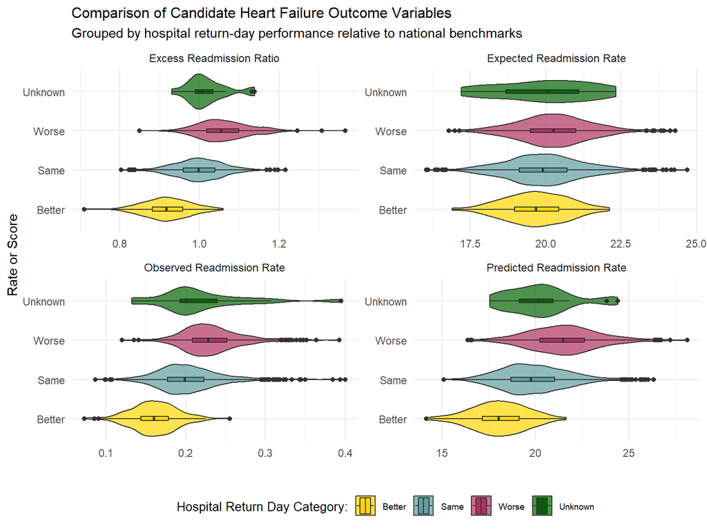

Figure 1. Comparison of candidate heart failure outcome variables by hospital return-day performance

#### **Question 2A**: [0.5 points]

If you have never encountered [violin plots](https://en.wikipedia.org/wiki/Violin_plot) before, they are honestly a wonderful way to assess the **symmetry** and **skew** of a distribution while more easily enabling comparisons between groups. They’re effectively a hybrid between a histogram and a boxplot, and we can even opt to overlay the boxplot quartiles in the plots as well, which is particularly handy!

**Your task** is to do just that by adding `geom_boxplot(width = 0.1)` (yes, just that one line!) in the appropriate place. Also change `include = FALSE` to `include = TRUE` in the R chunk header so that it shows up when you knit!

> Make sure to comment your line to call attention to it:

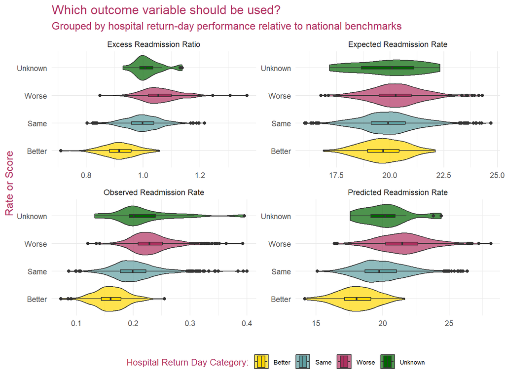

Figure 2. Comparison of candidate heart failure outcome variables by hospital return-day performance

#### **Question 2B**: [0.5 points]

Now that you can compare these groups more easily, what we’re looking for is a balance between **clear difference** between hospital ordinality relative to the national average (i.e., “Are better hospitals really better in pneumonia readmission rates?”).

Which target(s) appear the most distinct to you? > The Observed Readmission Rate and Predicted Readmission Rate appear to be the most distinct outcome variables. In both cases, hospitals classified as better performers generally exhibit lower readmission rates, while hospitals classified as worse performers exhibit higher readmission rates. The separation between groups is more apparent than for the Expected Readmission Rate or Excess Readmission Ratio. Because the Observed Readmission Rate represents the actual readmission experience of heart failure patients rather than a CMS-derived prediction, it appears to be the strongest candidate for the primary outcome variable in this analysis.

#### 2.3.2 Example with `geom_density()`:

We could also choose to overlay density plots instead of violin or boxplots, as this can sometimes help us see subtler separation of groups than we can see otherwise. This time, I am also going to ignore the “Unknown” (i.e., missing) class of hospitals to prevent things from getting too messy!

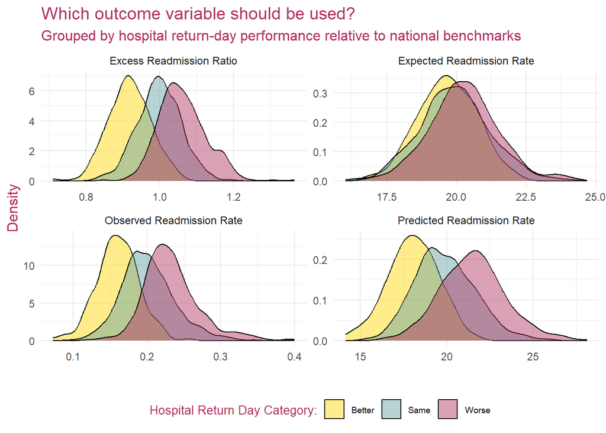

Figure 3. Comparison of candidate heart failure outcome variables using density plots

#### **Question 3**: [0.5 points]

Does this view confirm or change your decision from Question 3?

### 2.4 What is the relationship between heart failure readmissions and hospital performance metrics?

Another way to evaluate potential outcome variables is to examine how strongly they relate to hospital performance measures. By comparing candidate readmission outcomes with variables such as mortality rates, healthcare-associated infections, spending measures, and patient experience metrics, we can identify which outcomes appear most closely associated with overall hospital performance.

To explore these relationships, I will create another long-format dataset and use it to generate a series of faceted scatterplots. These plots will allow me to compare one of the candidate readmission measures against multiple hospital performance variables simultaneously and look for patterns or stronger associations. Although this visual approach is exploratory and should not be considered a formal variable-selection method, it can provide useful insight into which outcome variables may be most informative for subsequent predictive modeling.

#### **Question 4**: [1 point]

Change the **y-axis** out for _each of the four readmission rates. `Predicted Readmission Rates` has been started for you. Re-run the chunk and compare the results. **FOR FULL CREDIT** you must leave the graph on the choice you feel most strongly about AND update the title of the graph with which of the four possible readmission rates you chose. Explain below why you chose this one.

> I selected Predicted Readmission Rate because it showed the clearest separation between hospital performance groups and the strongest relationships with the quality measures. Since it adjusts for differences in patient populations, it is a better measure for comparing hospitals than the other readmission rate options.

**HINT 1**: What does higher medicare spending per patient tell you about the underlying population of a hospital?

**HINT 2**: Venous thrombolisms and deep vein thromboses (DVTs) are often “sneakier” conditions that have “silent” symptoms until the patient is in crisis. What would having higher scores at providing prophylaxis for these conditions potentially suggest about a hospital’s performance?

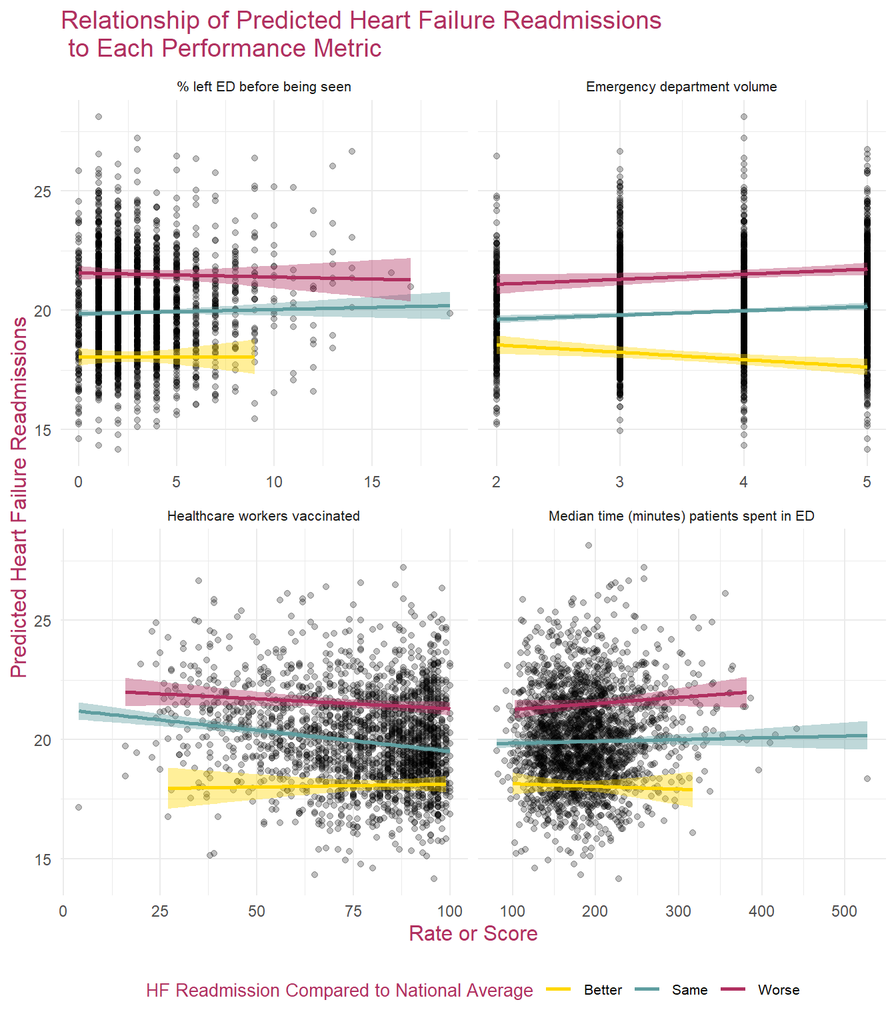

Figure 4. Predicted heart failure readmission rate by hospital performance and readmitted patient LOS

####2.5 What is the relationship of heart failure-related hospital readmissions to the patient satisfaction metrics?

Now let’s do a similar analysis but for the HcahpsLinear… variables. The HCAHPS (Hospital Consumer Assessment of Healthcare Providers and Systems) is a standardized survey that measures adult inpatient perceptions of hospital care. It is a nationally reported survey required by the Centers for Medicare & Medicaid Services (CMS). Because it focuses on aspects of care that are important to patients, it is commonly used to evaluate patient satisfaction and overall hospital quality.

#### **Question 5**: [1 point]

Again, you task is to change the **y-axis** out for _each of the four readmission rates. `Predicted Readmission Rates` has been started for you. Re-run the chunk and compare the results. **FOR FULL CREDIT** you must leave the graph on the choice you feel most strongly about AND update the title of the graph with which of the four possible readmission rates you chose. Explain below why you chose this one.

**HINT 1**: What does higher nurse and doctor communication mean for improved patient outcomes, including readmission?

**HINT 2**: Why might cleanliness have a weaker relationship with heart failure readmissions than communication, discharge planning, medication management, and care transitions?

#### **Question 6**: [2 points]

What relationships do you find most compelling from these scatterplots and why? Also, name one outstanding question you have at this point, whether it is about the data, the data collection, or something more speculative.

Although there is certainly more EDA we could do, we are going to wrap that up here for the sake of moving on - but, as always, I encourage you to think about or even explore what else you would like to know about your data that we did not do!

### 2.5 Final remarks on target selection.

Going forward, I have selected `PredictedReadmissionRate` as our target. In a more thorough analysis, we would likely want to consider:

1. Circling back to our stakeholder to try to refine our question or target using domain knowledge
2. Perform experiments with our models to find the best predictive model since that is our ultimate goal.

However, given that we do not have the option or time for that, let me explain my choice. It’s the **best balance** of distinguishing hospitals with better and worse readmitted hospital stays, while still providing an **adjusted, hospital-specific** measure. Adjusted values will generally always be a better choice than the crude, even if our crude measure captures something interesting about the data, as it did here, or if it’s easier for our stakholder to comprehend. Our crude measure, observed_readmission_rate did the best job of recapitulating the readmitted hospital LOS (Hospital return days for heart failure patients), but if that’s really our focus, wouldn’t it then be better to switch from a readmission rate to that as our target? Probably.

If you still feel unsure about what is the best choice, you’re not alone - so do I! This is where, because we are working with an **imagined stakeholder**, we must make the best decision we can given the question we defined in the Demo. I would defend my choice of `Predicted Readmission Rate` for three key reasons:

- It has been adjusted to be hospital-specific, using a hospital-specific intercept and historic data about the hospitals’ performances
- We don’t lose nearly 600 data points to missingness.
- Our imagined stakeholder, and the question we set, was about **readmission rate** so even though **readmitted return hospital days** might also be a similarly viable candidate, it doesn’t reflect our imagined stakeholder’s request. Note that the `ExpectedReadmissionRate` is standardized for similar hospitals, and may not truly reflect a given hospital; the `ExcessReadmissionRatio`, while informative, was the least likely to reflect the distinctiveness in hospital return days, which is still of interest to us.

But remember that what matters most is that we are **matching our question**.

#### **Question 7**: [1 point]

Do you agree with my choice of target? Why or why not? (You are free to disagree!) ANSWER: Yes, I agree with choosing PredictedReadmissionRate. It seemed to do the best job of balancing accuracy and usefulness while still keeping most of the data. It also showed clear relationships with several hospital performance and patient satisfaction measures. Although the observed readmission rate was interesting, I think the predicted rate is a better fit for the question we are trying to answer because it accounts for differences between hospitals and their patient populations.

### 2.6 Bias and Limitation

#### **Question 8**: [2 points]

All studies have bias (introduced or systemic error) and limitations (failure to fully explain something). We could go more deeply into these concepts, but for now I want you to take a stab and just brainstorming either ways we might have bias OR the limitations of using this target variable. You do not need to answer both, but you’re welcome to do so. You can read more about bias [here](https://www.ncbi.nlm.nih.gov/books/NBK574513/) or see some deeper explanations of limitations [here](https://www.aje.com/arc/how-to-write-limitations-of-the-study/). You do not need to write a lot; just 2-3 sentences. I am simply asking you to pause and reflect on our choices here before we proceed.

> One limitation of using PredictedReadmissionRate is that it is based partly on historical data and model adjustments, so it may not fully reflect a hospital’s current performance. In addition, factors such as patient health status, socioeconomic conditions, and access to follow-up care may influence readmissions but are not fully captured in the dataset.

# 3 Pre-processing and Feature Selection

The time has finally come to officially move **back** into pre-processing and feature selection so that we can finally build some models. I want you to take note of the order in which I’m doing things here; the flow can change from project to project, but generally it’s a good idea to get your dataset to a state of **manually curated features** before making your data partition.

## 3.1 Further feature selection and refinement.

### 3.1.1 Dropping the targets we aren’t planning to use. [Manual Method]

It’s time to say goodbye to the features we know would be far too redundant or non-informative given our target of `PredictedReadmissionRate`. We don’t need any of the `Sample_` columns, for example; these are merely sample sizes. Useful if we were doing standardization, but not necessary for us right now. We also are dropping the other possible target features that are too redundant with `PredictedReadmissionRate`.

#### **Question 9A**: [0.5 points]

Add your comments to the code as indicated to explain what I was doing at each of the steps.

> Your answer in the comments.

```r
dat2Analyze <- dat2Analyze %>%


  ## Remove alternative target variables and sample size fields that will not be used in modeling
  select(
    -ExpectedReadmissionRate,
    -ExcessReadmissionRatio,
    -observed_readmission_rate,
    -contains(c("Sample_", "NumberOfPatients"))
  ) %>%

  ## Rename long variable names to shorter, more readable names
  rename(
    `Median time (minutes) patients spent in ED` =
      `Average (median) time patients spent in the emergency department before leaving from the visit A lower number of minutes is better`,

    `Composite patient safety` =
      `CMS Medicare PSI 90: Patient safety and adverse events composite`
  ) %>%

  ## Move the target variable to the first column of the dataset
  select(
    PredictedReadmissionRate,
    everything()
  )

## Remove common prefixes from column names to make them easier to read
colnames(dat2Analyze) <- gsub(
  "Score_|HcahpsLinearMeanValue_|_Payment",
  "",
  colnames(dat2Analyze)
)
```

### 3.1.2 Dropping any features with near-zero variance. [Automated Method]

Next, we are going to take advantage of the `nearZeroVar()` function that is part of the `caret` package. We will drop any of the columns with near-zero variance. This is a way of automating (and thus standardizing) the process for choosing to drop non-informative columns due to zero or nearly zero variance.

#### **Question 9B**: [0.5 points]

If you are not familiar yet with the concept of **zero or near-zero variance**, do a little digging. Based on what you read, try to explain for your naive advocacy group stakeholders, why it’s important to remove the features with little variance.

> Features with little or no variance do not provide much useful information because they are nearly the same for every hospital. Since they do not help differentiate between hospitals with higher or lower readmission rates, they add unneeded details to the model without improving predictions. Removing these features can make the model simpler and more efficient.

Table 3. Columns dropped due to near-zero variance.

| Variables Dropped |
| --- |
| MRSA Bacteremia |
| Death rate for heart failure patients |
| Perioperative pulmonary embolism or deep vein thrombosis rate |

**Take note** of the number of features here.

#### **Question 9C**: [0.5 points]

You may or may not have noticed that I moved `FacilityID` to our rownames in the datasets you loaded today. Why did I choose to do that? Why do I want to make sure unique identifiers, like `FacilityID`, are out of the dataframe before I either (a) run `nearZeroVar()` or (b) proceed with the rest of the analysis?

> FacilityID is just a label for each hospital and doesn’t tell us anything about readmission rates. If we leave it in the dataset, the model might try to use it even though it has no real predictive value. Moving it out of the dataframe helps keep the analysis focused on variables that actually matter.

#### **Question 9D**: [1 point]

Do some research on, or lean into your previous knowledge, about the **curse of dimensionality** or the **big-P, little-N (n >> P) problem**. Using whatever you find or remember, can you justify why we likely do NOT have a **big-P, little-N (n >> P) problem** here? Make sure to explain.

> We probably don’t have a big-P, little-N problem because we have thousands of hospitals in the dataset but have a smaller number of features. The big-P, little-N problem happens when there are more variables than observations, which can make models overfit and struggle to find meaningful patterns. In our case, the number of observations is much larger than the number of predictors, so there is enough data to estimate relationships more reliably.

## 3.2 Assess missingness & devise an imputation plan

We are going to deal with imputation in a rather quick and elegant way that requires minimal effort from us using a model-based approach with `missForest`. You may recall from lecture that I said we are choosing a model-based approached *without uncertainty* because our ultimate goal is to create a deployable model for our stakeholder.

#### **Question 10**: [1 point]

Write some code that will quickly tally the number of columns in the dataset that contain missing values. You will find `colSums()` and `is.na()` functions likely useful here. **What percent of the features have at least some level of missingness?**

```r
# Count columns that contain at least one missing value
missing_cols <- sum(colSums(is.na(dat2Analyze)) > 0)

# Total number of columns
total_cols <- ncol(dat2Analyze)

# Percent of columns with missing values
percent_missing <- (missing_cols / total_cols) * 100

missing_cols
```

```
## [1] 27
```

```r
total_cols
```

```
## [1] 31
```

```r
percent_missing
```

```
## [1] 87.09677
```

**Which column(s) are not missing any data?**

**How many complete observations do we have in the dataset?** You may find `nrow()` with `complete.cases()` or `drop_na()` useful!

```r
sum(complete.cases(dat2Analyze))
```

```
## [1] 1636
```

There are 1636 complete observations in the dataset. These are hospitals that have data available for every feature without any missing values.

### 3.2.1 Use the `md.pairs()` function from the `mice` package to assess the extent of missing values before imputing.

When we are missing a lot of data, as we are here, it can sometimes be useful to predetermine whether the *patterns of missing correlate with our target*. Why? We care if missing values correlate with the target because this may indicate that the missingness itself carries information. Thus, ignoring it could lead to biased models or low predictive power!

In fact, missingness can itself **become a predictor**. If a missing value is associated with the outcome, it may carry predictive signal. For example, in our data, hospitals with high rates of missingness in Left before being seen that are highly associated with heart failure readmission might indicate a worrying pattern. Perhaps hospitals are negligently failing to report how many of their patients leave without being seen because of larger, systemic issues that ALSO happen to impact overall quality and patient care. Thus, missingness could itself become a predictor!

To do, I will leverage the `md.pairs()` function from the `mice` package which calculates the pairwise correlations of missingness between variables and allows us to visualize those patterns using a clustered heatmap. When I do this, I will drop `State` from the matrix because it will create errors if I retain it. (**Why?**)

```r
## Drop State and analyze the pairwise missingness using the mice package
miceMatrix <- md.pairs(dat2Analyze)
```

What `md.mice()` does is create two pairwise correlation matrices, `mr` and `mm`, where:

- `mr` = **Missing vs. Responded**
  - Pairwise matrix showing how often the row has a missing value in one variable and an observed (i.e., non-missing or “responded”) value in the other
- `mm` = **Missing vs. Missing**
  - Pairwise matrix showing how often the row has a missing value in one variable and missing value in the other variable

Let’s take a look at the first 6 rows and 4 columns of the `mr` matrix:

Table 4. Missing vs. Reponded Matrix Slice

|  | PredictedReadmissionRate | FacilityId | Score.x | Payment |
| --- | --- | --- | --- | --- |
| PredictedReadmissionRate | 0 | 0 | 0 | 0 |
| FacilityId | 0 | 0 | 0 | 0 |
| Score.x | 669 | 669 | 0 | 650 |
| Payment | 19 | 19 | 0 | 0 |
| Payment for heart failure patients | 15 | 15 | 0 | 0 |
| Abdomen CT Use of Contrast Material | 15 | 15 | 0 | 0 |

Now, let’s take a look at the first 6 rows and 4 columns of the `mm` matrix now:

Table 5. Missing vs. Missing Matrix Slice

|  | PredictedReadmissionRate | FacilityId | Score.x | Payment |
| --- | --- | --- | --- | --- |
| PredictedReadmissionRate | 0 | 0 | 0 | 0 |
| FacilityId | 0 | 0 | 0 | 0 |
| Score.x | 0 | 0 | 669 | 19 |
| Payment | 0 | 0 | 19 | 19 |
| Payment for heart failure patients | 0 | 0 | 15 | 15 |
| Abdomen CT Use of Contrast Material | 0 | 0 | 15 | 15 |

Similarly, `miceMatrix$mm[i, j]` gives us the number of cases where both variables $i$ and $j$ were co-missing.

#### **Question 11A**: [0.5 points]

Explain what you think the number in cell $[6,1]$ means. Out of all the observations in the dataset, does this feel like a high degree of co-missingness?

> The value in cell [6,1] is 0, which means there were no hospitals where both of those variables were missing at the same time. Out of the 2,305 hospitals in the dataset, this does not represent a high degree of co-missingness. In fact, it suggests there is no overlap in the missing values between those two variables.

Lastly, we can calculate a **proportion of missingness vs. response** between any two variables $i$ and $j$ such that:

$Proportion_{i,j} = \frac{mr_{i,j}}{mr_{i,j} + mm_{i,j}}$

In non-mathy speak, it’s the fraction of the times that variable $j$ is observed among rows where $i$ is missing. So, if you want to impute variable $i$ - let’s say it’s `MRSA Bacteremia` - then you will be interested in the variables typically **observed** (present in the dataset) when $i$ is missing. Those are the variables that will be able to help us predict, or fill in, $i$.

- If this ratio is close to 1, $j$ is nearly always available when $i$ is missing, so $j$ might be useful for imputing $i$.
- If this ratio is close to 0, $j$ is usually missing when $i$ is missing, so it’s not helpful for imputing $i$. You can also use this to tell you about **patterns of missingness with regard to your target variable when you target is** $i$.

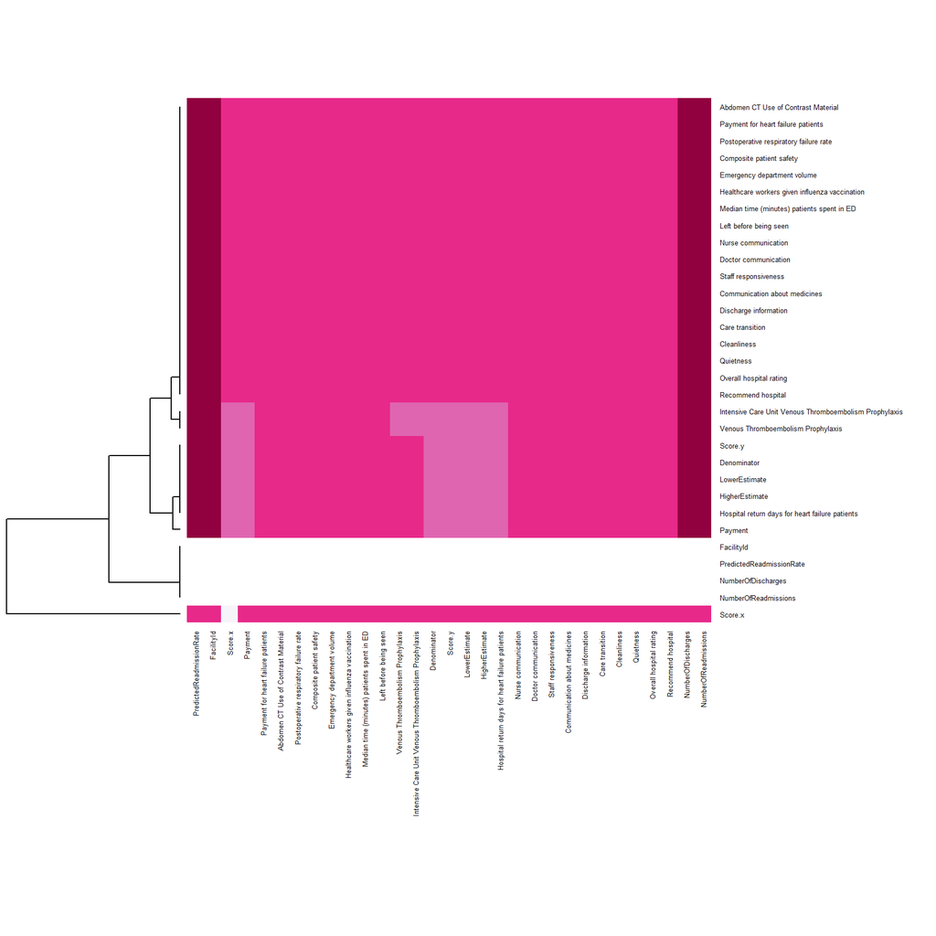

Figure 5. Correlation between Missing and Response

It may feel a little counterintuitive, but here **darker colors** indicate a higher correlation between missingness and response (proportions nearer to 1). In other words, these are the variables that are going to be more informative during imputation for a given variable.

But what if we wanted to know about patterns of missingness with regard to our target, `PredictedReadmissionRate`? Well, we could get that too!

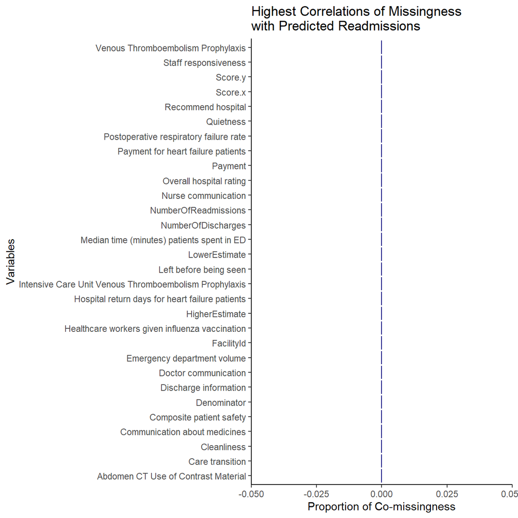

Figure 6. Correlation between Missing and Missing for Target

#### **Question 11B**: [0.5 points]

What columns seem to be most correlated in terms of missingness to our target, `PredictedReadmissionRate`? Does this give you any cause for concern? Feel free to speculate as to why you might see this.

> PredictedReadmissionRate has no missing values, so there is no meaningful co-missingness with the target. This is actually a good thing because the outcome variable is complete.

## 3.3 Drop rows that are missing from the target variable.

We cannot use observations that are missing the target variable. In this dataset, PredictedReadmissionRate does not contain any missing values, so no rows were removed and the dataset remains at 2,305 hospitals.

```
## [1] "Rows: 2305"  "Columns: 31"
```

#### **Question 12**: [0.5 points]

Thinking back to your answer to Question 9D, do you feel any differently given these dimensions of the dataset?

> Not really. We still have over 2,300 hospitals and only 31 variables, so there is much more data than predictors. Because of that, I do not think we have a big-P, little-N problem.

## 3.4 Do the splits!

At this stage, we are almost ready to **impute** - but not until we have done our data partitioning first! In fact, splitting our data into training and testing partitions first is really important to prevent **data leakage**.

#### **Question 13**: [1 point]

Explain to your stakeholder, in simpler language, (1) why we partition data into testing and training sets and (2) what data leakage is. You do not need to go into great detail, but it should explain enough that they understand the basic ideas.

> We split the data into training and testing sets so that we can build the model on one group of hospitals and then see how well it performs on data it has never seen before. This gives us a better idea of how the model will work in the real world. Data leakage happens when information from the testing data accidentally gets used while building the model, which can make the results look better than they really are and give a false impression of the model’s accuracy.

You may recall that I mentioned that the optimal ratio is has been argued to be $\sqrt{p} : 1$, where $p$ is the number of parameters (which may or may not equal your predictors depending on your planned analysis). Note that you do not have to split only a single time; you could make different splits for different analyses, if needed. However, we are going to use a single split here for convenience.

Now, wouldn’t it be nice to have a handy function that could calculate the optimal split ratio for us? So, let’s write one! This is something you can use with ANY analysis going forward!

#### **Question 14A**: [1.5 points]

There are three parts to this question to get it to all come together correctly.

1. Comment the function to explain what it does (I’ve defined the arguments for you)
2. Run the function (fill in the blank)
3. Fill in the missing piece in the data partitioning chunk below

```r
calcSplitRatio <- function(p = NA, df) {
  ## @p  = the number of parameters. by default, if none are provided, the number of columns (predictors) in the dataset are used
  ## @df = the dataframe that will be used for the analysis

  ## If p is not provided, use the number of predictors in the dataset
  if(is.na(p)) {
    p <- ncol(df) -1   ## Subtract 1 to exclude the target variable
  }

  ## Calculate the recommended number of observations in the test set
  test_N <- (1/sqrt(p))*nrow(dat2Analyze)

  ## Calculate the proportion of observations to place in the test set
  test_prop <- round((1/sqrt(p))*nrow(dat2Analyze)/nrow(dat2Analyze), 2)

  ## Calculate the remaining proportion for the training set
  train_prop <- 1-test_prop

  ## Display the recommended training/testing split ratio
  print(paste0("The ideal split ratio is ", train_prop, ":", test_prop, " training:testing"))

  ## Return the training proportion for later use
  return(train_prop)
}

## Fill in the blanks to run:
train_prop <- calcSplitRatio(df = dat2Analyze)
```

```
## [1] "The ideal split ratio is 0.82:0.18 training:testing"
```

**Hint**: One important note here is that if the number of parameters are not provided (which is true for the starter code I gave you to run it - it does NOT pass any parameters to that argument!), then by default our function is designed to take the number of columns of the dataframe and subtract one for the target variable. Neat, huh?

Now, uncomment this code and fill it out to run it.

```r
 ind <- createDataPartition(dat2Analyze$PredictedReadmissionRate,   ## Put the target here!
                            p = train_prop,           ## Use the object you just made!
                            list = FALSE)

 train <- dat2Analyze[ind, ]
 test <- dat2Analyze[-c(ind), ]
```

#### **Question 14B**: [0.5 points]

What split ratio did you get? Is it close to the canonical 80-20 split? Why do you think that happened?

> I got a 0.82:0.18 training-to-testing split, which is very close to the common 80:20 split. I think this happened because our dataset has a fairly large number of observations compared to the number of predictors, so the formula produced a sptlit that is close to the standard recommendation while still accounting for the size of the model.

**Did you get stuck somewhere?** If so, load the `test` and `train` data in case you struggled with Question 18 so you can proceed:

```r
#load(file = "FY2024_data_files/pneumoniaTrain.Rdata")
#load(file = "FY2024_data_files/pneumoniaTest.Rdata")
```

## 3.5 Impute missing variables using `missForest`.

We are going to take advantage of the `missForest()` function from the `missForest` package. In a nutshell, what `missForest` does is it will fit either a regression- or classification-based random forest model and use the OOB (“out-of-bag”) results to predict and fill in `NA`s. The advantage is that this process is non-linear, done in just a few lines of code, and can handle mixed data-types (although you need to make sure that all your numerical types are of the same numerical type, and that all characters or factors are of the same type).

#### 3.5.1 Running `missForest`

The way I have chosen to do this is to separate the data so that I can turn the encoded categories back into categories temporarily, then stitch them back together into a temporary dataframe so that I can run `missForest`. Notice that I temporarily drop the `State` and target features; I drop `State` to spare ourselves a little computational time and I drop `PredictedReadmissionRate` to prevent **data leakage**. **Be patient!!**. Since this is randomForest, it could take a minute or two to run. **NOTE:** *If your machine fails to run this, there are data you can load. Some computers may struggle to run this.*

```r
# Remove encoded categorical variables for imputation, plus the target and state (which have no missing)
data_sans_encoded = train %>%
  select(-PredictedReadmissionRate,
         -`Emergency department volume`,
         -contains("ComparedToNational"))

data_cat = train %>%
  select(`Emergency department volume`,
         contains("ComparedToNational")) %>%
  mutate_all(as.factor)

# Stitch them back together:
temp <- cbind(data_sans_encoded, data_cat)

# Convert any remaining character columns to factors
temp[] <- lapply(temp, function(x) {
  if(is.character(x)) as.factor(x) else x
})

# Impute missing values using missForest
imputedTrain <- missForest(temp,
                           variablewise = TRUE,
                           verbose = FALSE)
```

#### 3.5.2 Load this if it will not run for you

```r
#load(file = "FY2024_data_files/imputedTrain.Rdata")
```

#### 3.5.3 Quick summary of the results

**NOTE:** If yours didn’t run, make sure to look at the table output in the knitted HTML I provided you. Also, change the `include=FALSE` in the chunk header if you were not able to get `missForest` to run.

Table 6. missForest OOB Error Rates for the imputed variables, training dataset

| OOB Error | Variable |
| --- | --- |
| **MSE** |  |
| 0.00 | FacilityId |
| 0.38 | Score.x |
| 866254.54 | Payment |
| 0.05 | Payment for heart failure patients |
| 0.97 | Abdomen CT Use of Contrast Material |
| 0.13 | Postoperative respiratory failure rate |
| 0.10 | Composite patient safety |
| 0.91 | Healthcare workers given influenza vaccination |
| 0.97 | Median time (minutes) patients spent in ED |
| 0.67 | Left before being seen |
| 0.41 | Venous Thromboembolism Prophylaxis |
| 0.43 | Intensive Care Unit Venous Thromboembolism Prophylaxis |
| 8425.93 | Denominator |
| 13.12 | Score.y |
| 15.63 | LowerEstimate |
| 24.31 | HigherEstimate |
| 0.01 | Hospital return days for heart failure patients |
| 0.59 | Nurse communication |
| 0.63 | Doctor communication |
| 0.78 | Staff responsiveness |
| 0.76 | Communication about medicines |
| 0.76 | Discharge information |
| **PCF** |  |
| 0.59 | Care transition |
| 0.81 | Cleanliness |
| 0.84 | Quietness |
| 0.56 | Overall hospital rating |
| 0.70 | Recommend hospital |
| 0.00 | NumberOfDischarges |
| 0.00 | NumberOfReadmissions |
| 0.42 | Emergency department volume |

#### **Question 15**: [1 point]

What does `MSE` (Mean Squared Error) and `PCF` (Proportion of Falsely Classified) indicate here? You may find looking at the `missForest` [Vignette](https://stat.ethz.ch/education/semesters/ss2012/ams/paper/missForest_1.2.pdf) helpful. Which variable(s) had the highest OOB error?

> MSE (Mean Squared Error) measures how close the imputed values are to the actual values for numeric variables. Lower MSE values indicate more accurate imputations. PCF (Proportion of Falsely Classified) measures how often categorical variables are assigned the wrong category during imputation, so lower values are also better. Based on the OOB error results, Payment had the highest error, followed by Denominator, HigherEstimate, and LowerEstimate. These variables appear to have been the most difficult for the model to impute accurately.

**NOTE 1**: If the OOB error (either MSE or PCF) from `missForest` is really high, it’s a red flag that the imputation for those variables is untrustworthy. This could be do to too much missingness, weak relationships among the variables making it hard to predict, or low quality data (e.g., noisy, sparse). In such cases, we want to **DROP** any variables with extremely high OOB error because they add noise. A general rule of thumb is that if the PCF > ~0.3 (30% of the imputed values are wrong) or if there is especially high MSE (inflation) relative to the variance of the variable, we should drop it. Let’s set those aside so we can drop them from `test` and `train` both downstream!

```r
## These look okay, which is why we won't drop them.
## Uncomment to see their variances.
var(train$`Venous Thromboembolism Prophylaxis`, na.rm = T)
```

```
## [1] 134.6681
```

```r
var(train$`Healthcare workers given influenza vaccination`, na.rm = T)
```

```
## [1] 319.6704
```

```r
cols2drop <- c("Payment for pneumonia patients", "Emergency department volume")
```

#### **Question 16**: [1 point]

Alternatively, we could use MICE (Multivariate Imputation with Chained Equations), which is a method that will model uncertainty along with the variables. Do a little research. How does MICE work? Include a citation to a source.

> MICE (Multivariate Imputation by Chained Equations) fills in missing values by using the other variables in the dataset to predict them. It does this one variable at a time and repeats the process several times until the imputations stabilize. Unlike single imputation methods, MICE creates multiple imputed datasets, which helps account for the uncertainty caused by missing data and can lead to more reliable results.

Citation: van Buuren, S., & Groothuis-Oudshoorn, K. (2011). mice: Multivariate Imputation by Chained Equations in R. Journal of Statistical Software, 45(3), 1–67. https://doi.org/10.18637/jss.v045.i03

#### 3.5.4 Putting it alllllll back together…

We are almost done with imputation. The last thing we need to do is extract the imputed values from `imputed_data$ximp`, and add the `State` and target variable back. Then we get to wash, rinse, and repeat for the test set! Oh my!

##### 3.5.4.1 Put the original `State` and `target` variables back

```r
imputedTrain <- imputedTrain$ximp %>%
  mutate(
    PredictedReadmissionRate = train$PredictedReadmissionRate
  )
```

##### 3.5.4.2 Now do the imputation for `test`

```r
# Remove encoded categorical variables for imputation, plus the target and state
data_sans_encoded <- test %>%
  select(
    -PredictedReadmissionRate,
    -contains("ComparedToNational")
  )

# Keep categorical variables as factors
data_cat <- test %>%
  select(contains("ComparedToNational")) %>%
  mutate_all(as.factor)

# Stitch them back together
temp <- cbind(data_sans_encoded, data_cat)

# Convert any remaining character columns to factors
temp[] <- lapply(temp, function(x) {
  if (is.character(x)) as.factor(x) else x
})

# Impute missing values using missForest
imputedTest <- missForest(
  temp,
  variablewise = TRUE,
  verbose = FALSE
)
```

##### 3.5.4.3 Load this if it will not run for you

```r
#load(file = "FY2024_data_files/imputedTest.Rdata")
```

##### 3.5.4.4 Put the original `State` and `target` variables back on `test`

```r
#imputedTest <- imputedTest$ximp %>%
 # mutate(
  #  PredictedReadmissionRate = test$PredictedReadmissionRate
 # )
```

##### 3.5.4.5 Drop the features we determined we should not retain due to unstable imputation from BOTH `train` and `test`

```r
#imputedTrain <- imputedTrain[, !(names(imputedTrain) %in% cols2drop), drop = FALSE]
#imputedTest  <- imputedTest[, !(names(imputedTest) %in% cols2drop), drop = FALSE]
```

#### **Question 17**: [1 point]

Quickly explore how well the imputation did by choosing at least one numeric variable and one of the categorical variables. Did the distributions or frequencies change drastically? You may find the `summary()` and `table()` functions to be fastest here.

```r
# Numeric variable
summary(train$`Payment for heart failure patients`)
```

```
##    Length     Class      Mode
##      1893 character character
```

```r
summary(imputedTrain$`Payment for heart failure patients`)
```

```
##      Greater Than the National Average Payment
##                                            331
##         Less Than the National Average Payment
##                                            244
## No Different Than the National Average Payment
##                                           1315
##                                  Not Available
##                                              2
##                      Number of Cases Too Small
##                                              1
```

```r
# Categorical variable
table(train$`Emergency department volume`, useNA = "ifany")
```

```
##
##          high           low        medium Not Available     very high
##           460           225           658            28           512
##          <NA>
##            10
```

```r
table(imputedTrain$`Emergency department volume`, useNA = "ifany")
```

```
##
##          high           low        medium Not Available     very high
##           460           226           667            28           512
```

## 3.6 Another Fork in the Road

It’s time, yet again, to make a choice. If you opted to load the **fully encoded** dataset and everything has been done on that, you will run the first chunk. But if you decided that you wanted to **wait to encode** the TIME HAS FINALLY COME!

### 3.6.1 The Left Fork - No Encoding, Just Converting Data Back After `missForest`

Ultimately, we need to turn the factor features back into numbers for our next analyses but we had to turn them into factors for `missForest`. So, now we need to turn them back. Notice a bit of annoying trickery here. Because we had converted them to a factor type, in order to back-convert them correctly to our original ordinal encoding, we had to first convert to character and then to numeric. So, our conversion goes **factor** $\rightarrow$ **character** $\rightarrow$ **numeric** in order to get exactly what we need! Again, we must remember to perform on BOTH `imputedTrain` and `imputedTest`.

```r
# Extract imputed dataframes from missForest objects if needed
if ("missForest" %in% class(imputedTrain)) {
  imputedTrain <- imputedTrain$ximp
}

if ("missForest" %in% class(imputedTest)) {
  imputedTest <- imputedTest$ximp
}

# Convert factors/characters back to numeric
readyTrain <- imputedTrain %>%
  mutate_if(is.factor, as.character) %>%
  mutate_if(is.character, as.numeric)

readyTest <- imputedTest %>%
  mutate_if(is.factor, as.character) %>%
  mutate_if(is.character, as.numeric)
```

### 3.6.2 The Right Fork - Frequency Encoding

The time has FINALLY come to do frequency encoding, if that is the fork in the road you took all the way back in Section 1.3. Once again, we will be using a helper function that we load with the `source()` function like we did here. It will do the frequency encoding for us on the `State` variable, if it needs to be done. If you started from the fully encoded dataset, there is a conditional statement that will skip this for you.

```r
## This calls the helper function in the associated .R file
#source(file = "doFrequencyEncoding.R")

## If State is not already a number
#if(!is.numeric(imputedTrain$State)) {
    ## This sets a list of COLUMN NAMES I want to frequency encode
 #   cols2encode <- c("State")

    ## This runs the function, which takes up to 4 arguments
    ## Open the source code to see what each argument does!
    ## It returns a LIST of frequency encoded dataframes.
  #  freqEncoded <- doFrequencyEncoding(train = imputedTrain,
   #                                    test = imputedTest,
    #                                   cols2encode = cols2encode,
     #                                  quiet = FALSE)

    ## Lastly, extract the newly encoded, imputed, dataframes!
    #readyTrain <- freqEncoded$train
    #readyTest <- freqEncoded$test
#}
```

#### **Question 18**: [1 point]

Because we are now frequency encoding AFTER data partitioning (we did ordinal encoding BEFORE the split for convenience), we absolutely **must** apply the same encoding map to the `test` set that we did to the `train` set. Explain why, and what should we do if some classes of the variable end up in the `train` that is not in the `test` or vice versa? (**HINT**: Look at the source code!)

> We need to use the same frequency encoding map from the training set on the test set so that categories are assigned the same values in both datasets. Otherwise, the model could interpret the same category differently and make poor predictions. If a category appears in the test set but not the training set, we should assign a default value (or handle it the way the source code specifies) since there is no frequency information available from the training data.

## 3.7 Transformation & Scaling

Ultimately, we know we will need to scale & center our data, as that is required for the analyses I have set out in our Analysis Plan. But before we get into that, it would be nice to know what **realm of analyses** in which we fall and, more importantly, do we need to consider *transformation* of our target in addition to the scaling & centering we plan to do on the entire dataset.

**In other words: is our target variable approximately normally distributed?**

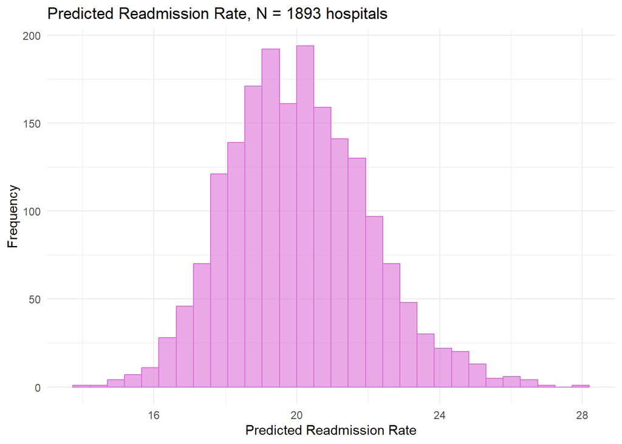

Figure 7. Histogram of Raw Predicted Readmission Rate

#### **Question 19A**: [1 point]

Why is a histogram, or even a Q-Q plot, an insufficient way to assess whether a distribution is approximately normal?

> Histograms and Q-Q plots provide a visual assessment of normality, but they can be subjective because different people may interpret the same graph differently. The appearance of a histogram can also change depending on the number of bins used. For this reason, it is often helpful to use numerical measures or statistical tests in addition to visual inspection when assessing whether a distribution is approximately normal.

Now Apply a [Shapiro-Wilk test](https://biostats.w.uib.no/test-for-normality-shapiro-wilks-test/) for normality using the `shapiro.test()` function. What does it indicate about your distribution? (**Note**: Shapiro tests are only reliable for $N < 5000$, but it is fine to perform here.)

```r
shapiro.test(readyTrain$PredictedReadmissionRate)
```

```
##
##  Shapiro-Wilk normality test
##
## data:  readyTrain$PredictedReadmissionRate
## W = 0.99265, p-value = 0.0000000393
```

### 3.7.1 Box-Cox Transformation

The Box-Cox transformation is a *family* of power transformations used to stabilize variance and make data more normally distributed (Box & Cox, 1964). Recall from our brief discussion in lecture that the Box-Cox transformation involves the parameter $\lambda$, which when applied to $y$ yields the transformation. It is defined as

$y^\lambda = \frac{y^\lambda - 1}{\lambda}$ for $\lambda \ne 0$.

When $\lambda = 0$, it is the same as the $\ln(y)$. Our lecture slides have more reference values for how to interpret $\lambda$. But if $\lambda \ne 0$, then this means that the transformation is only applicable to positive values. The end result is that it helps improve the performance of statistical models that assume normality.

#### 3.7.1.1 There are multiple ways to apply the Box-Cox transform in R, but we are going to take advantage of the one in `caret` to make our lives easier, `BoxCoxTrans()`.

```r
bc_data <- BoxCoxTrans(readyTrain$PredictedReadmissionRate)
print(paste0("Box-Cox lambda =  ", bc_data$lambda))
```

```
## [1] "Box-Cox lambda =  -0.2"
```

#### 3.7.1.2 Now, apply the Box-Cox transformation to the `train` data:

```r
readyTrain$bc_PredictedReadmissionRate <- predict(bc_data, readyTrain$PredictedReadmissionRate)
```

#### 3.7.1.3 Assess how it did:

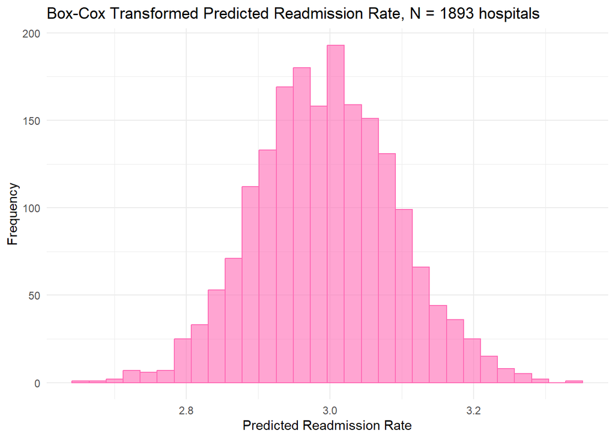

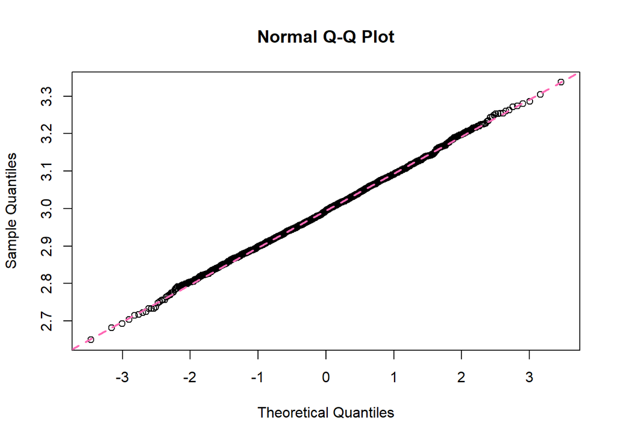

##### Figures 8a-b. Predicted Readmission Rate After Box-Cox Transformation

Can you see what it did to the distribution? **look closely**, if not. It’s subtle but discernible!!

#### **Question 19B**: [1.5 points]

Now repeat all of the steps to perform a Box-Cox transform on your own to the `imputedTest` data. Why must we (1) also transform the test data and (2) **use the same $\lambda$ as the training data**?

> We must also transform the test data so it is on the same scale as the training data. We also need to use the same lambda value from the training data to avoid data leakage and keep the datasets consistent. The Box-Cox transformation improved the distribution by making it more symmetric and reducing skewness.

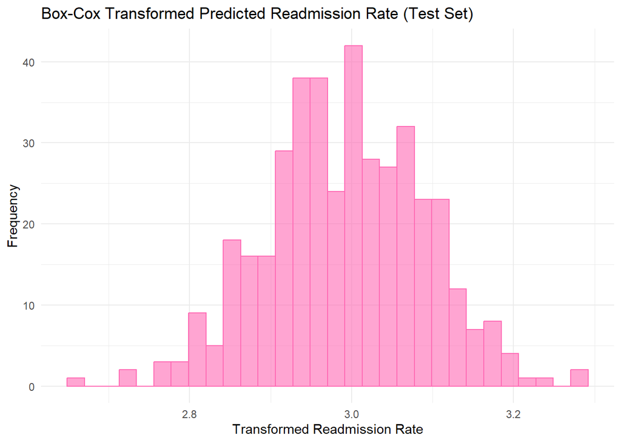

```r
# Apply the same Box-Cox transformation from the training set
readyTest$bc_PredictedReadmissionRate <- predict(
  bc_data,
  test$PredictedReadmissionRate
)

# Check the transformed distribution with a histogram
ggplot(readyTest, aes(x = bc_PredictedReadmissionRate)) +
  geom_histogram(
    alpha = 0.6,
    fill = "hotpink",
    color = "hotpink"
  ) +
  theme_minimal() +
  labs(
    title = "Box-Cox Transformed Predicted Readmission Rate (Test Set)",
    y = "Frequency",
    x = "Transformed Readmission Rate"
  )
```

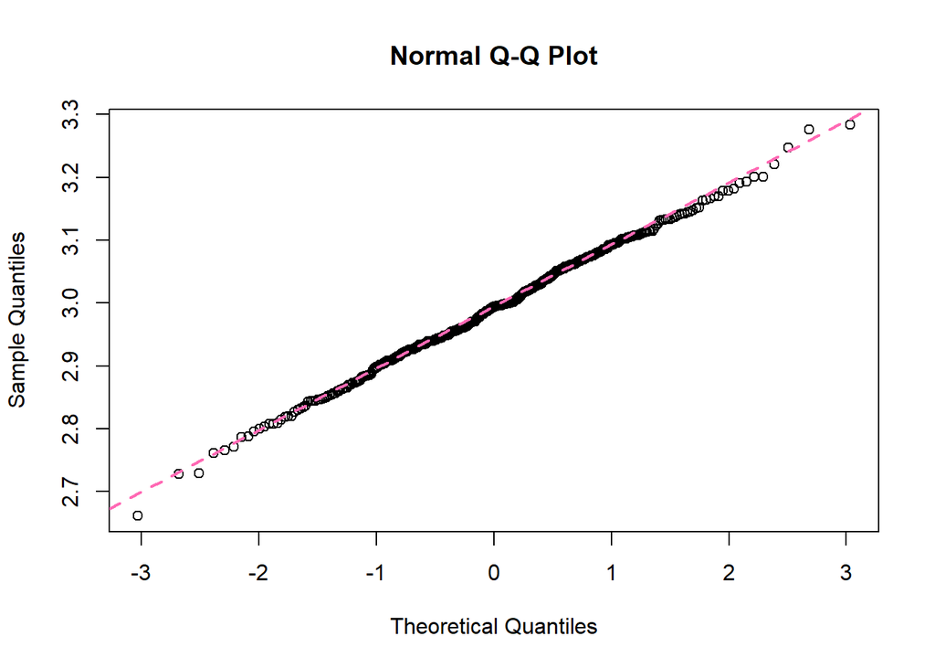

```r
# Check normality with a Q-Q plot
qqnorm(readyTest$bc_PredictedReadmissionRate)

qqline(
  readyTest$bc_PredictedReadmissionRate,
  col = "hotpink",
  lty = 2,
  lwd = 2
)
```

**NOTE** At this point, you have both an non-transformed (`PredictedReadmissionRate`) and Box-Cox transformed (`bc_PredictedReadmissionRate`) version of the target in your data.

### 3.7.2 Centering & Scaling

Now that we have applied a Box-Cox transform to the target variable, we can center and scale the remainder of the variables. We had to perform the Box-Cox *prior* to centering because the data has to be positive for a Box-Cox transformation (unless we switch to a [Yeo-Johnson transform (Yeo & Johnson, 2000)](https://academic.oup.com/biomet/article-abstract/87/4/954/232908)). Centering will likely make a lot of the data negative, plus we know we have negatives in our dataset purposefully.

It’s time to drop the *original* target, `PredictedReadmissionRate`, and center and scale everything INCLUDING the target! Here it is for the training set:

```r
readyTrain <- readyTrain %>%
  ## Drop the original target variable
  select(-PredictedReadmissionRate) %>%
  ## Make anything that might still be a factor from encoding is back to number
  mutate_if(is.factor, as.numeric) %>%
  ## Center and scale everything!
  scale(center = TRUE, scale = TRUE) %>%
  data.frame()
```

#### **Question 19C**: [0.5 points]

Do the same for your test data. Make sure to use `readyTest` and overwrite it.

```r
# Drop original target only if it still exists
if ("PredictedReadmissionRate" %in% names(readyTest)) {
  readyTest <- readyTest %>%
    select(-PredictedReadmissionRate)
}

# Convert factors and scale
readyTest <- readyTest %>%
  mutate_if(is.factor, as.numeric) %>%
  scale(center = TRUE, scale = TRUE) %>%
  data.frame()
```

**Hint**: Make sure to turn your centered, scaled **matrix** back into a dataframe! By default, it creates a matrix.

### 3.7.3 To save time, you are welcome to start from here after you’ve worked through the above steps.

```r
#load(file = "FY2024_data_files/readyTrain.Rdata")

#load(file = "FY2024_data_files/readyTest.Rdata")
```

# 4 Assessing Multicollinearity & Feature Redundancy

As we finally, finally wrap-up pre-processing there is one final assessment we need to perform: **multicollinearity**. As I am certain you recall, multicollinearity is when we have high correlation between predictors (so much so, in fact, that it comes at the cost of any correlation with the target!). Recall from lecture that multicollinearity is when one or more of our predictors are moderately to highly correlated with each other. This can **inflate our coefficients** and thereby cause spurious associations through **false positives** (i.e., small p-values when we don’t actually have them!).

Here we will implement two common ways we assess multicollinearity: pairwise correlations and Variance Inflation Factors (VIFs).

## 4.1 Pairwise Correlation

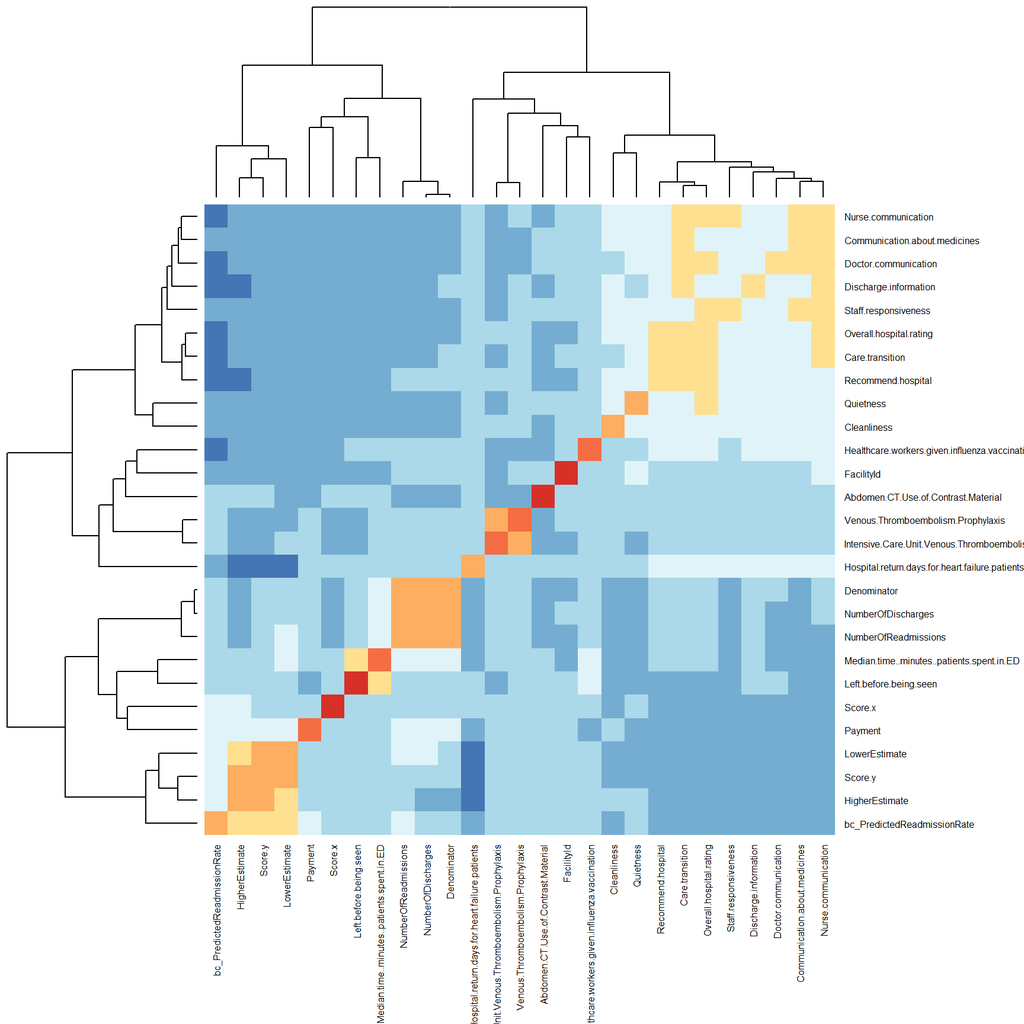

Figure 9. Correlation Heatmap of All Variables

#### **Question 20A**: [1 point]

Where do you see the highest potential for multicollinearity? Why do you say that?

> The highest potential for multicollinearity is among the patient satisfaction variables, such as nurse communication, doctor communication, staff responsiveness, and overall hospital rating. These variables are grouped closely together on the heatmap and appear strongly related to one another.

Which variable(s) seem to be most correlated with our target, `bc_PredictedReadmissionRate`?

## 4.2 Fitting a model to estimate VIF

Another way we can assess multicollinearity is by fitting a multiple linear regression model and estimating the **variance inflation factors**, or VIF, which estimates how much the variance of an estimated regression coefficient increases if your predictors are correlated. Specifically, variance inflation can identify **multicollinearity** when the VIF is greater than ~4 and especially when it is above 10.

## 4.2.1 Fit a linear regression with the training data, using the Box-Cox transformed `Predicted Readmission Rate` as the target.

```r
# Remove columns that are entirely NA
readyTrain <- readyTrain[, colSums(is.na(readyTrain)) < nrow(readyTrain)]

# Remove rows with remaining missing values
readyTrain <- na.omit(readyTrain)

# Fit linear regression model
mod <- lm(
  bc_PredictedReadmissionRate ~ .,
  data = readyTrain
)
```

## 4.2.1 Next, let’s calculate the VIFs using the `vif()` function that is part of the `car` package.

Note that I am not printing all of the VIFs, just the top 15 after sorting in descending order.

```r
## Calculate the VIFs and put into a dataframe to print the table
vifResults <- vif(mod) %>% data.frame
## Change the column names of the dataframe
colnames(vifResults) <- c("VIF")
```

Table 7. Top 15 Variance Inflation Factors after multiple linear regression

|  | VIF |
| --- | --- |
| Score.y | 1564.52 |
| LowerEstimate | 451.48 |
| HigherEstimate | 412.21 |
| NumberOfDischarges | 105.90 |
| Denominator | 62.27 |
| NumberOfReadmissions | 39.56 |
| Overall.hospital.rating | 35.66 |
| Recommend.hospital | 23.05 |
| Nurse.communication | 11.03 |
| Care.transition | 9.15 |
| Staff.responsiveness | 6.17 |
| Communication.about.medicines | 5.67 |
| Doctor.communication | 4.67 |
| Discharge.information | 4.39 |
| Venous.Thromboembolism.Prophylaxis | 3.51 |

#### **Question 20B**: [1 point]

Does multicollinearity seem to be an issue in this dataset and, if so, among which variables? Why do you come to this conclusion?

**HINT 1**: What was used to calculate `Overall Hospital Rating`? Does this help us better understand why the VIF is so large?

**HINT 2**: Is, for example,`Payment Category for pneumonia patients` created from `Payment for pneumonia patients`? [These are Medicare payments]? Which one do you think we should keep amd why?

> Yes, multicollinearity appears to be an issue in this dataset. Variables such as Overall hospital rating, Recommend hospital, and Nurse communication have high VIF values, suggesting strong relationships among the patient satisfaction measures. HigherEstimate and LowerEstimate also have extremely large VIF values, indicating overlapping information.

Which variable(s) seem to be most highly correlated with our target? Is it a positive or negative correlation? Does it make sense?

### 4.3 Dropping the most collinear variables

Even though we plan to proceed with an elastic net (which is much more robust to multicollinearity), some of these VIFs are too high for comfort. We also want to pause and ask - **were any of the variables used to make other variables?** (The answer is “yes”!). Those are excellent candidates to scrub too; we want to use our domain knowledge and what our stakeholders are asking for to help us decide which ones to keep.

Because the goal is a deployable predictive model, we want to reduce redundant predictors and keep the more detailed variables when possible. Several patient satisfaction measures and estimate variables appear highly correlated, so removing the most collinear features should help simplify the model and reduce instability.

### 4.3.1 Drop variables with VIF over 5 from both the training and testing data

```r
## Drop those with VIF over 5
vifOver5 <- vifResults %>% filter(VIF >=5) %>% rownames()
print(vifOver5)
```

```
##  [1] "Denominator"                   "Score.y"
##  [3] "LowerEstimate"                 "HigherEstimate"
##  [5] "Nurse.communication"           "Staff.responsiveness"
##  [7] "Communication.about.medicines" "Care.transition"
##  [9] "Overall.hospital.rating"       "Recommend.hospital"
## [11] "NumberOfDischarges"            "NumberOfReadmissions"
```

```r
## Now drop them
readyTrain <- readyTrain %>% select(-any_of(vifOver5))
readyTest <- readyTest %>% select(-any_of(vifOver5))
```

### 4.3.2 Now drop all of the `ComparedToNational` and `PaymentCategory` features **except** `ComparedToNational_Hospital return days for pneumonia patients`

```r
# Drop remaining ComparedToNational and PaymentCategory variables
readyTrain <- readyTrain %>%
  select(
    -contains("Compared"),
    -contains("PaymentCategory"),
    -any_of("SurveyResponseRate")
  )

readyTest <- readyTest %>%
  select(
    -contains("Compared"),
    -contains("PaymentCategory"),
    -any_of("SurveyResponseRate")
  )
```

# 5 Unsupervised Learning Methods: Segmentation Analysis

Predictive modeling is our ultimate goal, but let’s pretend our stakeholders have expressed a desire to better understand how the hospitals relate to one another and whether there are any general patterns we should be interested in for enhanced interpretation. After all, a prediction is one thing, but understanding the *why* is still usually important!

Thus, we have opted to undertake a **Segmentation Analysis** to see if there is any underlying segments, or clusters, of hospitals based on the data we have. We will use the unsupervised methods of Principal Component Analysis (PCA) and $k$-means clustering do this; it will help us to determine if there are broader classifications of our hospitals that we need to report back to the advocacy group.

## 5.1 Principal Component Analysis

First, we apply a PCA on the data and display the principal components. Note that we have the same number of **principal components** as we do variables in the data set! The *cumulative proportion* of variance adds to 100% by our last principal component; but we’re really more interested in the portion of variance explained by EACH of the principal components. This can help us figure out just how many PCs are important for explaining the most variance. For example, if we were interested in feature reduction, we could use the top PCs that explain, say, some portion of the variance that we wish to retain.

#### **Question 21**: [2 points]

1. At what principal component do we surpass 80% of explained variance? (**HINT**: look at the cumulative variance row rather than tha proportion of variance row).

```r
pca <- prcomp(readyTrain)
summary(pca)
```

```
## Importance of components:
##                           PC1    PC2    PC3     PC4     PC5     PC6    PC7
## Standard deviation     1.9323 1.5560 1.2978 1.17859 1.09300 1.08922 0.9674
## Proportion of Variance 0.2262 0.1467 0.1020 0.08416 0.07238 0.07188 0.0567
## Cumulative Proportion  0.2262 0.3729 0.4749 0.55911 0.63148 0.70336 0.7601
##                            PC8     PC9    PC10    PC11    PC12    PC13    PC14
## Standard deviation     0.88941 0.84156 0.79867 0.73003 0.69319 0.65675 0.48844
## Proportion of Variance 0.04793 0.04291 0.03865 0.03229 0.02911 0.02613 0.01445
## Cumulative Proportion  0.80799 0.85090 0.88954 0.92183 0.95094 0.97707 0.99153
##                           PC15
## Standard deviation     0.37398
## Proportion of Variance 0.00847
## Cumulative Proportion  1.00000
```

2. You may also notice that this is always ordered from most proportion of variance on the left (thus is PC1 defined) to our final principal component on the right. What percent of variance is explained by just PC1? What percent by the final PC? Is the attributable portion of the variance in PC1 high, medium, or low based on some quick research or prior knowledge?

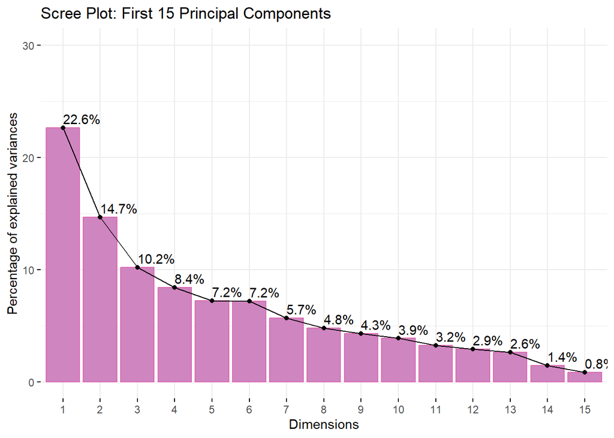

Figure 10. Scree Plot of First 15 Principal Components

How many PCs appear optimal to you based on the scree plot?

> Based on the scree plot, approximately 5–6 principal components appear to be optimal. The explained variance decreases sharply from PC1 through PC5 and then begins to level off around PC6, indicating diminishing returns from retaining additional components. Retaining the first 5–6 principal components would likely capture most of the meaningful variation in the data while reducing dimensionality.
4. People often mis-write scree (I’ve even accidentally done it) as SCREE, as if it’s an acronym like AUROC or ROC or even PCA. But it’s not. Why is it called a scree plot? (**Hint**: It may not be what you expect!)

> A scree plot gets its name from scree, which is the pile of loose rocks that collects at the bottom of a mountain. The shape of the plot looks similar—a steep drop at first and then a flatter section—so the name stuck. The “elbow” is where the steep part starts to level off, which helps us decide how many principal components to keep.

### 5.1.2 Variable loadings and contributions

Next, let’s explore how much the variables are contributing (this is based on the weight of their rotations). In PCA, we are interested in the **loadings**, i.e., the linear combination weights (coefficients) whereby unit-scaled components define or “load” a variable. Loadings help us interpret principal components.

You may have noticed we used the `prcomp()` function above; `prcomp()` will return the loadings in the variable `$rotation`, which contains a matrix of variable loadings. These loadings have been determined from the eigenvectors, which without getting into what that is (because we’d have to take a departure into linear algebra), suffice it to say that they are how we are measuring the direction and magnitude during each subsequent rotation of the principal components as we measure the variance explained.

Additionally, we are going to color this by our grouping variable and key predictor in the dataset, Hospital.return.days.for.heart.failure.patients. This variable reflects hospital performance related to heart failure return-to-hospital days compared with the national average. Hospitals categorized as “Worse than average” had heart failure patients with longer-than-average return stays.

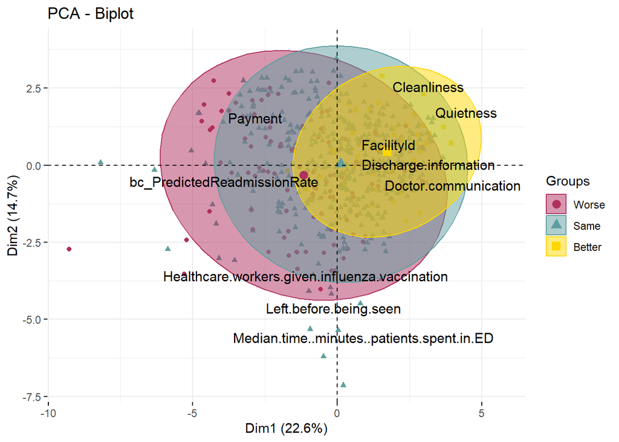

Figure 11. PCA Biplot Showing the Top Feature that Contributes to Explained Variance

This biplot (Figure above) shows that, on principal components 1 and 2 (the PCs that account for the most variance in the training data), there is subtle but noticeable grouping of hospitals based on heart failure return-to-hospital days. Variables such as Cleanliness, Quietness, Discharge.information, and Doctor.communication appear associated with hospitals in the “Better” category, while variables such as bc_PredictedReadmissionRate and Payment are more associated with the “Worse” category. Although the groups overlap, there appears to be some separation in the PCA space.

**A general rule of thumb is:**

1. Top-right Quadrant I
- PC1 and PC2 are both positive
- Thus points in this quadrant are positively associated with variables pointing into this quadrant
- Indicates high values for variables with arrows in this quadrant
2. Top-left Quadrant II
- PC1 is negative, PC2 is positive
- Thus points here are associated with high values of variables pointing to the left and top
- These observations contrast with those in the right-side quadrants on PC1
3. Bottom-left Quadrant III
- PC1 and PC2 are both negative
- Thus points here are negatively associated with variables pointing into the other quadrants
- These points could represent a distinct subgroup or pattern with behavior opposite to other points.
4. Bottom-right Quadrant IV
- PC1 is positive, PC2 is negative
- Thus points here are associated with variables pointing *into* this quadrant
- May indicate a contrast with Quadrant II on PC2

#### **Question 22**: [1 point]

Play around with the graphical parameters in the biplot, especially those I’ve marked with comments. Try adding, for example, more variables to display rather than just the top contributor. **NOTE** that if you find variables in the same quadrant together, this means that they are correlated. What variable(s) can you find that **contrast** with `Communication.about.medicines`?

Now, look at the contributions to PCs 1 and 2 (Figure Below) from the variables in the training dataset. Anything above the dotted red-line contributes **significantly** to the overall explanation of variance, and anything below the dotted line does not. Does anything about this plot stand out to you?

**HINT 1**: What do the top contributing variables all have in common? In other words, did they all come from the same data source?

**HINT 2**: Where does the target, `PredictedReasmissionRate`, fall among the significant variables?

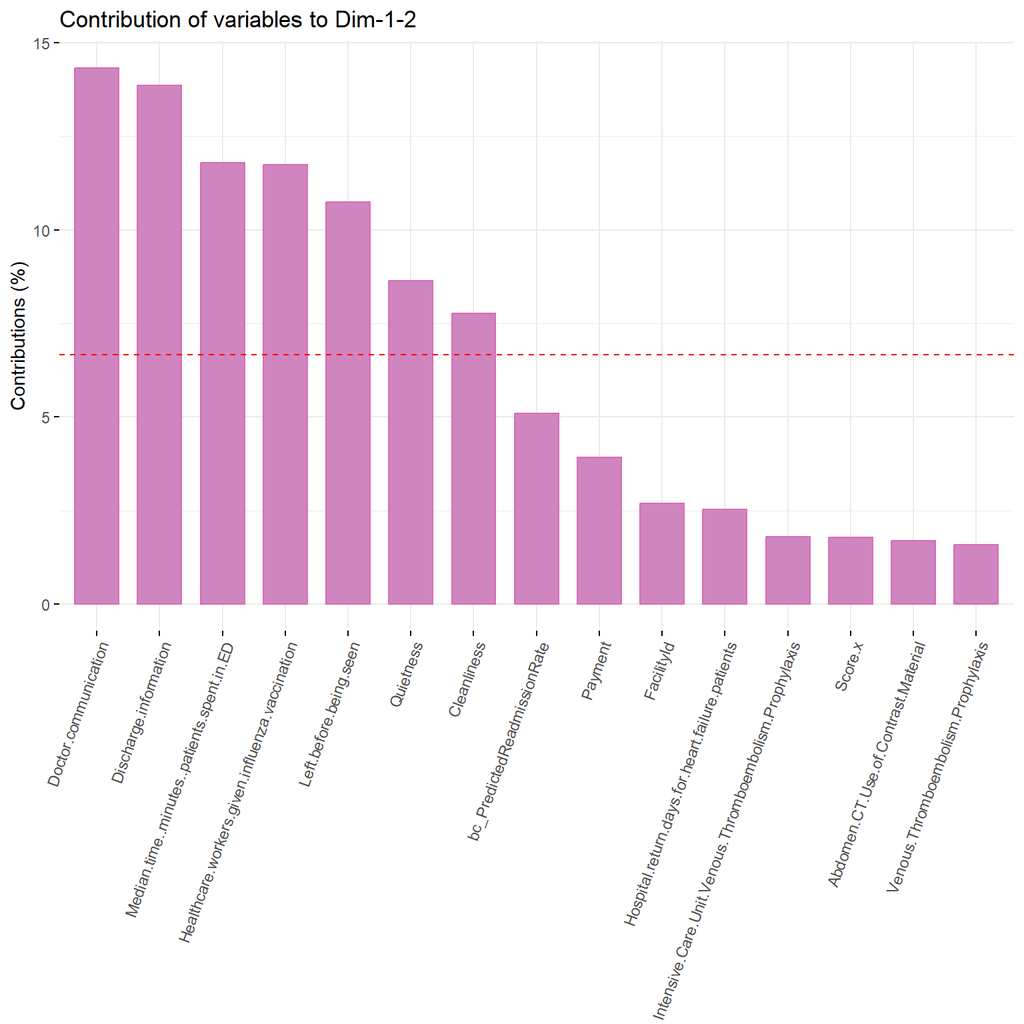

Figure 12. Variables that Significantly Explain Variance.

## 5.2 *k*-means Clustering

$k$-means is a centroid-based clustering algorithm, where a “centroid” is the geometric center of an object often measured by Euclidean distance. In the algorithm, the distance between each data point and a centroid is calculated by randomly grabbing data; these distances are then used to assign the data point to a cluster. The goal is to identify the optimal $k$ number of groups in a dataset by minimizing the distance of each datapoint to a respective centroid.

### 5.2.1 Visualizing Clusters

Although multiple methods exist to determine the optimal number of clusters, one commonly employed is **heuristic**, i.e., it isn’t really computational. You will either choose the optimal clusters based on a set of options of $k$ graphically or you can once again employ the “elbow” method again, as you did with PCA. Let’s start by visually inspecting the effect of different $k$ clusters on PC1 and PC2 of the dataset. I have chosen to test $k$ groups of 2 through 9.

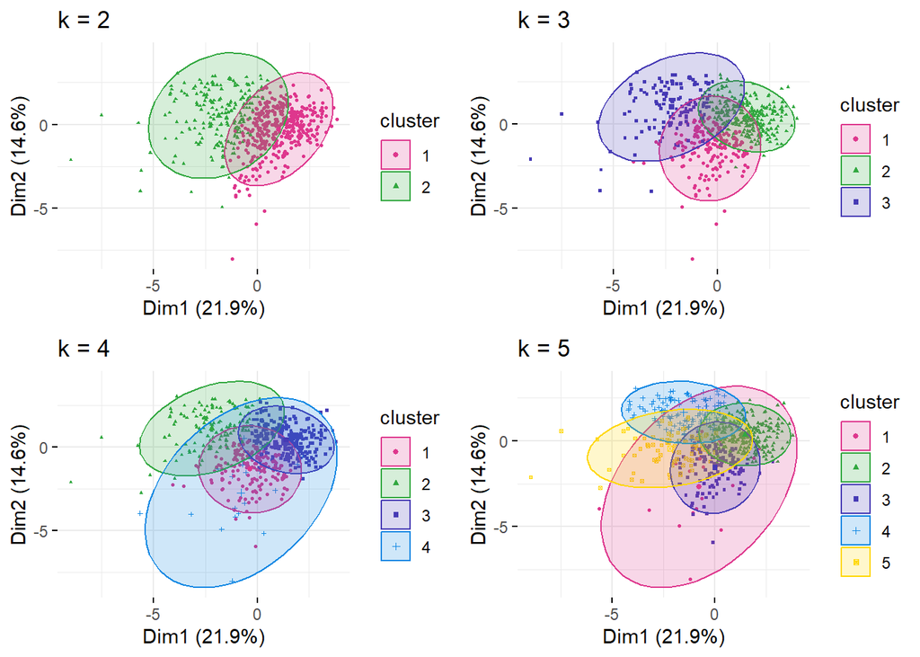

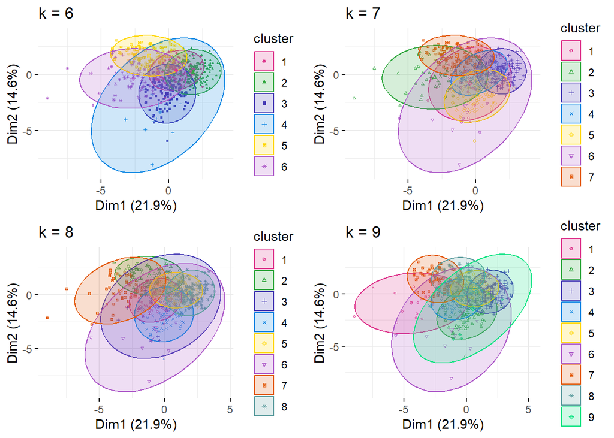

##### Figure 13. Biplots showing possible k clusters

#### **Question 23A**: [0.5 points]

Which number of clusters, $k$, do you think has the best explanatory power? Why? Is it is hard to tell?

> I think k=4 looks best. It separates the data into distinct groups without creating too much overlap. Lower values miss some patterns, while higher values mostly split existing groups into smaller clusters. It’s a little hard to tell from the plots alone, but k=4 seems to be the best balance.

### 5.2.3 Within-sum-of-squares (WSS) elbow method

Next, let’s employ the ‘elbow’ method again, this time to look at when the **within sum of squares** drops off rather than the percent variance, as was done in PCA.

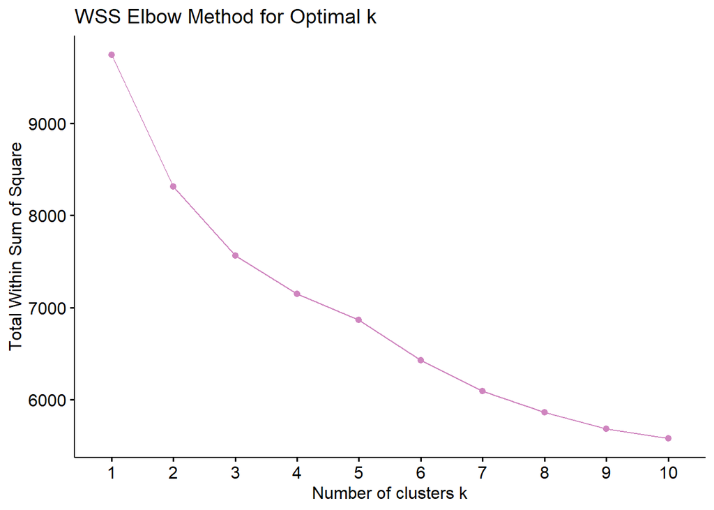

Figure 14. WSS Scree plot for k-means

#### **Question 23B**: [1 point]

What is the **within sum of squares** and what exactly is it measuring here? By the elbow method, which $k$ is the optimal number of clusters? Did it agree with your choice from the other heuristic method?

> The within sum of squares (WSS) measures how close the data points are to the center of their assigned cluster. Smaller WSS values indicate tighter and more compact clusters. The elbow appears around k=4, where the decrease in WSS starts to level off, suggesting that 4 is the optimal number of clusters. This agrees with my choice from the cluster plots.

### 5.2.3 Silhouette method

Lastly, we will apply the **silhouette method**, which measures the average silhouette width, a combination of (1) how similar any given point is to its own cluster (also called **cohesion**) and (2) how different that same point is from other clusters (also called **separation**). Silhouette scores can range from $-1 \rightarrow +1$, with larger values indicating better clustering (i.e., more cohesive clusters that are separated from each other). Thus, a silhouette score of 1 indicates **perfect separation and cohesion** whereas a silhouette of 0 indicates overlapping clusters.

What we can do is iteratively test our possible $k$ values of 2 to 9 and a silhouette score will be calculated for each $k$ tested. The highest silhouette score indicates the optimal $k$.

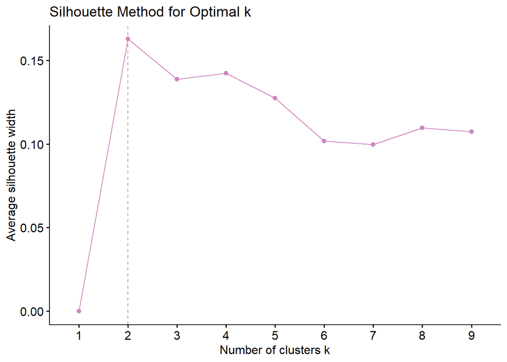

Figure 14. Silhouette Plot for k-means

#### **Question 23C**: [0.5 points]

Are you surprised at the optimal $k$ from the silhouette method? Does it seem to agree with what you’ve seen with the WSS elbow method? (**Hint**: agreement generally suggests evidence that you have found the optimal $k$).

> Yes, I was a little surprised that the silhouette method chose k=2, since the cluster plots and WSS elbow method suggested k=4. The two methods do not fully agree, which makes the optimal number of clusters less clear. However, the silhouette scores are relatively low overall, suggesting that the clusters are not strongly separated.

Lastly, let’s extract the optimal $k$ from the silhouette method.

```r
## Extract optimal k from silhouette method; first get the cluster data
clusterData <- fviz_nbclust(readyTrain, kmeans, method = "silhouette")$data
## Then extract the maximum y
k <- as.numeric(clusterData$clusters[which.max(clusterData$y)])
```

## 5.3 Segmentation Analysis

As we said before, the goal of segmentation analysis is to broadly cluster our hospitals by their features to help us characterize them.

#### **Question 24**: [1 point]

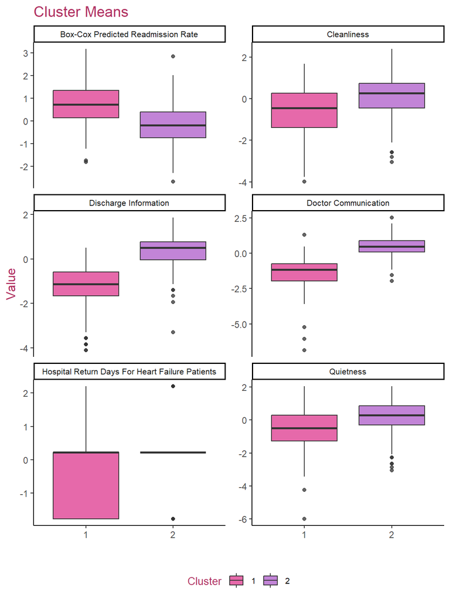

Figure 16. Boxplot Comparisons of Important Variables by Cluster

```r
## Run k-means clustering using the optimal number of clusters
kmeansResult <- kmeans(
  readyTrain,
  centers = k,
  nstart = 50,
  iter.max = 1000,
  algorithm = "MacQueen"
)

## Create dataset for cluster comparisons
kmeansTrain <- readyTrain %>%

  ## Remove unnecessary variables
  select(
    -any_of(vifOver5)
  ) %>%

  ## Add cluster assignments
  mutate(
    cluster = kmeansResult$cluster
  ) %>%

  ## Clean column names
  clean_names()

## Important variables from PCA contribution plots
pcaImportantVars <- c(
  "doctor_communication",
  "discharge_information",
  "cleanliness",
  "quietness",
  "hospital_return_days_for_heart_failure_patients",
  "bc_predicted_readmission_rate"
)

## Create boxplots comparing variables across clusters
kmeansTrain %>%

  ## Keep only important variables
  select(cluster, any_of(pcaImportantVars)) %>%

  ## Convert to long format
  pivot_longer(
    -cluster,
    names_to = "Measure",
    values_to = "Value"
  ) %>%

  ## Create cleaner labels
  mutate(
    Measure = case_when(

      Measure == "doctor_communication" ~
        "Doctor Communication",

      Measure == "discharge_information" ~
        "Discharge Information",

      Measure == "cleanliness" ~
        "Cleanliness",

      Measure == "quietness" ~
        "Quietness",

      Measure == "hospital_return_days_for_heart_failure_patients" ~
        "Hospital Return Days For Heart Failure Patients",

      Measure == "bc_predicted_readmission_rate" ~
        "Box-Cox Predicted Readmission Rate",

      TRUE ~ Measure
    )
  ) %>%

  ## Create boxplots
  ggplot(
    aes(
      x = as.factor(cluster),
      y = Value,
      fill = as.factor(cluster)
    )
  ) +

  geom_boxplot(alpha = 0.75) +

  scale_fill_manual(
    values = c(skittles[1], skittles[6])
  ) +

  labs(
    title = "Cluster Means",
    x = "",
    fill = "Cluster"
  ) +

  theme_classic() +

  theme(
    legend.position = "bottom",
    strip.text = element_text(size = 8),
    legend.text = element_text(size = 8),
    legend.title = element_text(size = 10),
    title = element_text(size = 12,
                         color = "maroon")
  ) +

  ## Separate panels for each variable
  facet_wrap(
    ~ Measure,
    scales = "free_y",
    ncol = 2
  )
```

#### **Question 25**: [2 points]

Look at how else you might broadly characterize - or segment - these hospitals. Your job is to make a table for your client, summarizing each of the two clusters with FOUR primary criteria. Make sure to give each cluster an informative name as I did; you’re welcome to rename Cluster 1 if you think of a catchier name than I chose!

After you come up with names of the two clusters, you will then come up with at least FOUR characteristics per cluster summarizing what you see in either the boxplots or table. You may choose to focus on different attributes for different clusters. Fill in the code for the table below. I start you out with two examples for Cluster 1, but feel free to add more!

Table 9. Hospital segmentation analysis showing two broad hospital groupings.

[output not shown]

## 5.4 Final Remarks on Segmentation

We don’t technically have to stop our segmentation analysis here, but we will so that we can focus on other analyses. One thing we might choose to do in the future, for example, is to choose a classification machine learning algorithm to test the predictions based on these clusters.

#### **Question 26**: [1 point]

Make a recommendation for our client for 1-2 machine learning analyses **your team** would choose to use to test whether these clusters can be used for robust predictions of hospital performance for pneumonia patients. How would you know whether or not your predictions were robust? What would you look for or compare?

> Our team would test these clusters using Random Forest and logistic regression models to predict hospital performance outcomes such as heart failure readmission risk. To evaluate robustness, we would compare model performance on a separate test dataset using metrics such as accuracy, precision, and recall. We would also compare model performance with and without the cluster assignments to determine whether the clusters improve prediction accuracy.

# 6 Supervised Learning Methods

We are going to perform two supervised learning methods: an Ordinary Least Squares (OLS) regression followed by an Elastic Net.

## 6.1 Ordinary Least Squares (OLS) regression

Earlier in Section 4 when we assessed multicollinearity, we fit an OLS regression model so that we could calculate variance inflation factors (VIFs). However, because OLS regression is so incredibly sensitive to multicollinearity, we should re-run it now that we’ve removed some of the most redundant variables.

Let’s model that now, using the `readyTrain` dataset and plot some diagnostic plots. to assess the key assumptions of an OLS linear regression. The four plots are diagnostic plots for the primary assumptions of a linear regression:

1. **Linearity** between the outcome and the predictors
2. **Normally distributed** residuals
3. **Homosecadasticity** (equality of variances) in the residuals
4. **No high leverage/influence points** (no significant outliers)

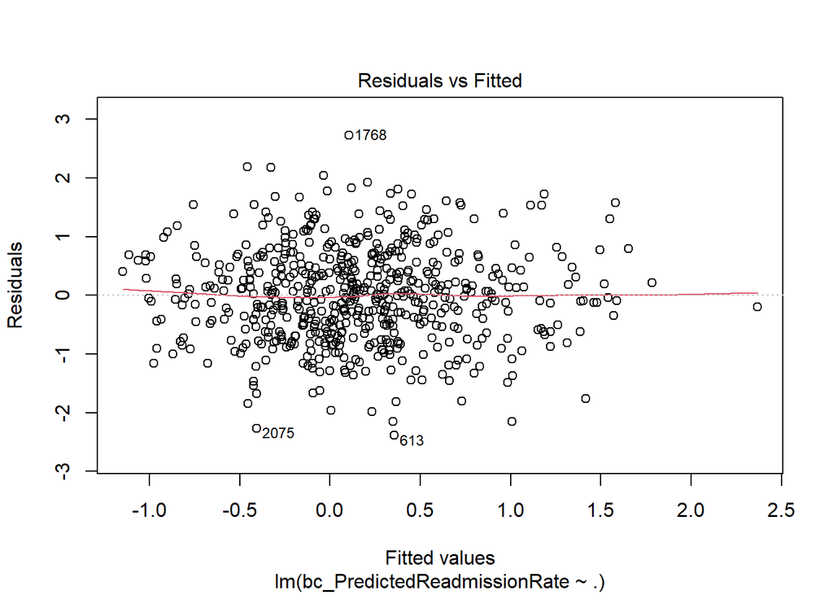

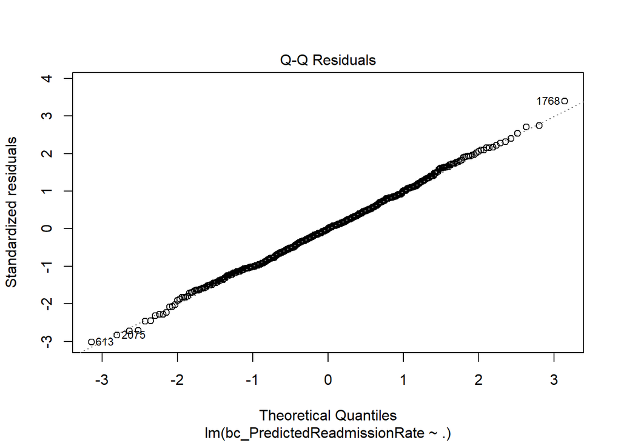

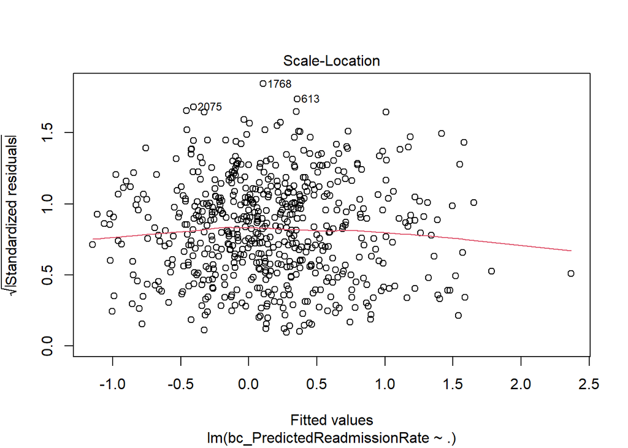

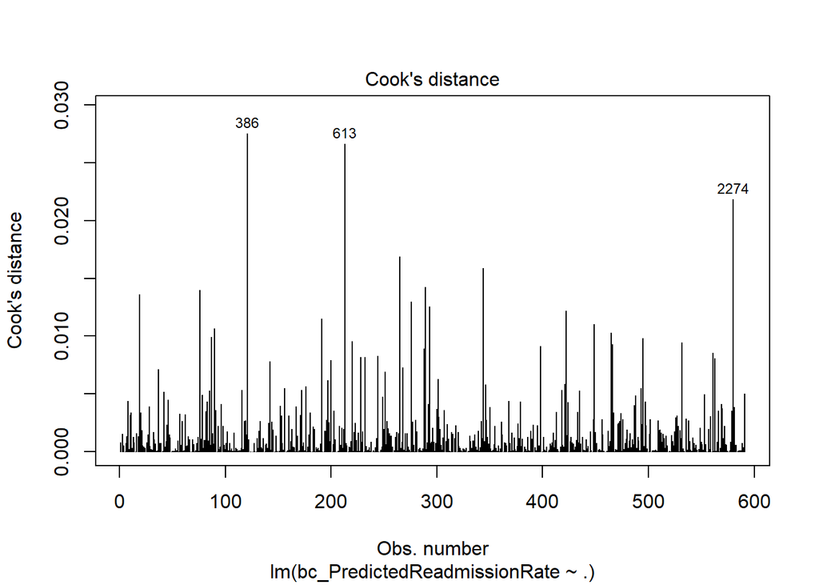

##### Figure 17. OLS Regression Assumption Diagnostic Plots

#### **Question 27A**: [1 point]

What is your general assessment of our OLS assumptions? Met or unmet? Why?

**Note:** If you are not entirely sure about the Q-Q plot, you can run a Shapiro-Wilk test on the residuals using the following code:

```r
shapiro.test(residuals(mod))
```

```
##
##  Shapiro-Wilk normality test
##
## data:  residuals(mod)
## W = 0.99838, p-value = 0.866
```

The **most important** OLS assumption for Elastic Net is **linearity of the relationship between predictors and the response**. The other, stricter OLS assumptions don’t matter as much because of regularization.

**Do you find support for linearity here**? Why or why not?

> Yes, there is support for linearity. The Residuals vs Fitted plot shows residuals randomly scattered around zero with a relatively flat trend line, suggesting no strong nonlinear relationship between the predictors and the response.
2. Let’s now assess how well our model fits with the adjusted $R^2$.

```
## [1] 0.3048204
```

#### **Question 27B**: [1 point]

> We use adjusted R-squared because it accounts for the number of predictors included in the model, while regular R-squared will almost always increase when additional variables are added, even if they contribute very little. Adjusted R-squared provides a more realistic measure of model performance and helps reduce the risk of overfitting.
3. Find the best model.

Use the `step()` function to do a backward regression to find our **most parsimonious** model. Stepwise regression drops terms that are not significant or important, thereby only keeping the features that contribute to the overall explanation of variance in predicted readmission rate.

```r
## Perform a backward, stepwise regression to find the most parsimonious model
bestMod <- step(mod,
            direction = "backward",
            trace = FALSE)
```

Lastly, let’s take a peek at the results. We will use a package called `stargazer` to help us visualize the results in a nicely organized way.

```r
## Print a table using stargazer
stargazer(bestMod,
          type = "html",
          title = "Table 10. Parsimonious OLS Regression Results.")
```

**Table 10. Parsimonious OLS Regression Results.**

|  | *Dependent variable:* |
| --- | --- |
|  | bc_PredictedReadmissionRate |
| Score.x | 0.084** |
|  | (0.035) |
| Payment | 0.115*** |
|  | (0.036) |
| Abdomen.CT.Use.of.Contrast.Material | 0.046 |
|  | (0.028) |
| Healthcare.workers.given.influenza.vaccination | -0.108*** |
|  | (0.034) |
| Left.before.being.seen | 0.075** |
|  | (0.033) |
| Hospital.return.days.for.heart.failure.patients | -0.287*** |
|  | (0.034) |
| Doctor.communication | -0.250*** |
|  | (0.034) |
| Constant | 0.052 |
|  | (0.035) |
| Observations | 591 |
| R<sup>2</sup> | 0.316 |
| Adjusted R<sup>2</sup> | 0.307 |
| Residual Std. Error | 0.807 (df = 583) |
| F Statistic | 38.399*** (df = 7; 583) |
| *Note:* | p<0.1; p<0.05; p<0.01 |

Lastly, let’s assess how good a predictive model our OLS regression model is. We will use the `predict()` function to first fit our most parsimonious model `bestMod` to the test data:

```r
## Make the predictions
predictions <- predict(bestMod, newdata = readyTest)
```

The Root Square Mean Error ($RMSE$) is the square root of the average of the squared differences between predicted and actual value, such that $RMSE = \sqrt{\frac{1}{n}\sum_{i=1}^n\cdot(y_i-\hat{y}_i)^2}$ where $y_i$ is each observed value, $\hat{y}_i$ is each corresponding predicted value, and $n$ is the number of observations. **NOTE**: Recall that a residual is $y_i-\hat{y}_i$ - the distance between every point and its predicted value! It’s also important to realize that the $RMSE$ gives more weight to large errors because of squaring. Thus, it’s sensitive to outliers.

#### **Question 27C**: [1 point]

Can you interpret what the RMSE tells your client here? Why or why not? What about the $R^2$?

**Hint 1**: Remember that the outcome here is Box-Cox transformed. Would you need to undo the transformation to be able to assess what the RMSE (or $R^2$) is actually telling us? Recall that the Box-Cox $\hat{y} = \frac{1}{y^\lambda}$ where our $\lambda = -0.3$ AND we also centered and scaled these data.

**Hint 2**: Is it practical to undo both transformations? How does that hinder our ability to make an interpretation for our client?

> The RMSE and R-squared describe model performance, but they are difficult to interpret directly because the outcome variable was Box-Cox transformed and standardized. As a result, these metrics are more useful for comparing models than for interpreting actual readmission rates.

Lastly, let’s graph the effect predictive ability of our OLS model by comparing the relationship between the **true** values of `bc_PredictedReadmissionRate` from the `readyTest` dataset to the predictions we made using the model on the testing data.

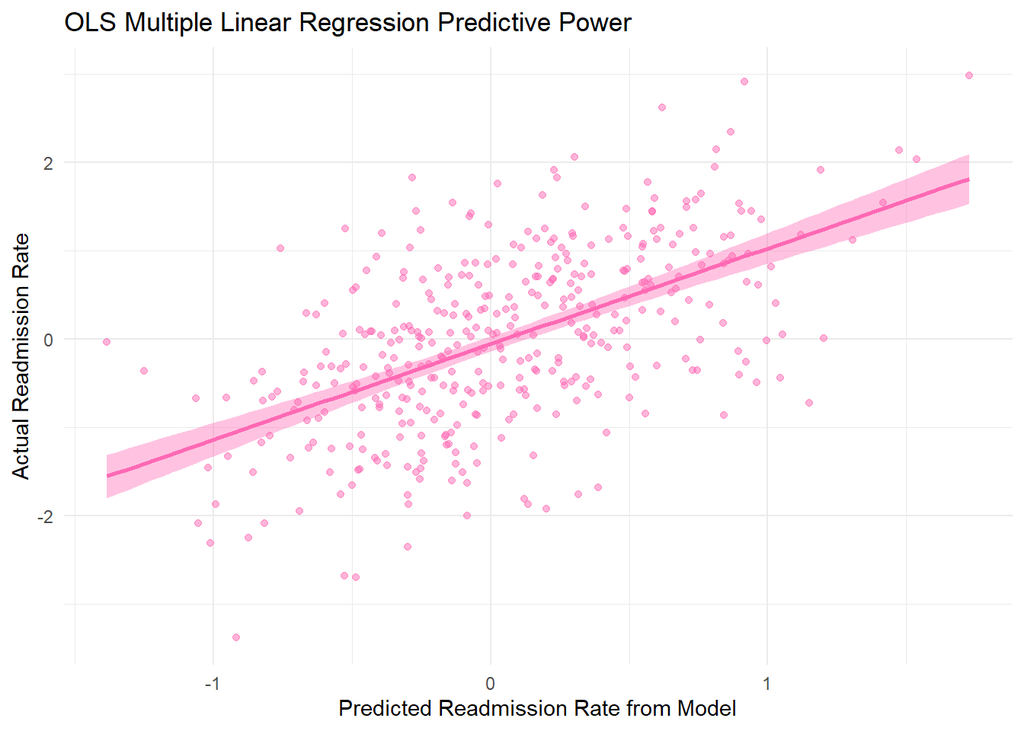

Figure 18. Predictions Plot for OLS Regression

**NOTE** that, while there is an obvious linear trend, it is weak. There is a lot of error around the predictions from the OLS regression!

## 6.2 The Elastic Net

Perhaps the seemingly low $R^2$ is because we still have too much multicollinearity or overfitting. So, as we discussed in lecture, we can address this using regularized regressions, such as the **Elastic Net**, which is more robust to multicollinearity by assessing penalties for non-zero variance. Typically, we would likely conduct a Ridge and/or LASSO before running an Elastic Net, but since we already know that (1) we have a fairly high amount of multicollinearity in our original `readyTrain` dataset and (2) we know we want to be able to perform feature reduction and figure out which features are important predictors of hospital readmissions, we’re going to jump straight into Elastic Net, which performs both.

### 6.2.1 The Elastic Net Unpacked

In general, regularization is a technique that applies a penalty term to a cost function of a machine learning model, like the OLS regression. The reason is to discourage overfitting. This penalty term constrains the model’s coefficients, which limits how flexible they are during training. Why?

The more flexible the coefficients, the less likely they will “learn” new data, i.e., the more generalizable they are! Thus, by applying this penalty (constraint), it improves the model’s performance on “unseen” or new data.

As mentioned in lecture, Elastic Net regression is a general regularization technique that combines the regularization techniques of Ridge and LASSO to help us perform both feature selection (i.e., significant coefficients) and feature reduction (importance). The elastic net can even help us with the $P >> n$ problem! Elastic net has two regularization terms, called **L1** (or the Lasso regularization term) and **L2** (the Ridge term).

- **L1**: makes some of the coefficients zero, thereby selecting only the most important features (shrinks them to zero). It is often said that this **encourages sparsity in the model**.
- **L2**: reduces the coefficients to small but non-zero values, thereby reducing the coefficients of the unimportant features (which we can use to determine significance). It does this by adding a penalty term to the cost function of the model, which is proportional to the coefficient squared. This allows us to retain all the features in the model but reduces the overall impact of the non-significant or less-important ones.

Thus, by combining these techniques together, the Elastic Net is balancing feature selection with feature reduction! If you’re interested in reading the original paper on Elastic Net by Zou and Hastie (2005), you can find a free PDF of the paper [here](https://www.stat.purdue.edu/~tlzhang/mathstat/ElasticNet.pdf).

### 6.2.2 Running, tuning, & cross-validating the Elastic Net

The elastic net can be run using the `glmnet` package (which we are accessing via `caret`), and can be cross-validated as random forest and SVM from our last project could be. This is a big improvement over OLS regression, which cannot be tuned. Additionally, the elastic net has **two hyperparameters** that we can tune, $\alpha$ and $\lambda$ (not to be confused with the $\lambda$ from Box-Cox transformation - Greek letters are abundant in statistics! Why do you think I named our course teams as I did?!).

#### 6.2.2.1 We will start by setting our CV parameters just as we did on the last project, using the `trainControl()` function in `caret`.

```r
ctrl <- trainControl(method = "repeatedcv",  ## Do repeated CV
                     number = 5,             ## Number of k-folds
                     repeats = 5,            ## Number of repeats
                     search = "grid",        ## Grid search (vs. random)
                     verboseIter = FALSE)    ## Don't show me all the results
```

#### 6.2.2.2 Then, we fit the model using the `train()` function in `caret`, specifying that we want to perform an elastic net, which will tune the model and perform CV per the specifications in the `trainControl()`. **NOTE** that I am allowing the values of $\alpha$ to range from $0 \rightarrow 1$ and allowing $\lambda$ to range from $0 \rightarrow 5$.

```r
library(caret)
library(glmnet)

## Define cross-validation scheme
ctrl <- trainControl(method = "cv",
                     number = 10)

## Create tuning grid
searchGrid <- expand.grid(.alpha = seq(0, 1, length.out = 10),
                          .lambda = seq(0, 5, length.out = 15))

## Fit elastic net
elasticMod <- train(bc_PredictedReadmissionRate ~ .,
                    data = readyTrain,
                    method = "glmnet",
                    tuneGrid = searchGrid,
                    trControl = ctrl)
```

#### **Question 28**: [1 point]

Explain what we are doing here. You may want to look up the parameters of the `trainControl()` and `train()` functions. Make sure to address what type of CV and hyperparameter search is being performed, as well as if both the $\alpha$ and $\lambda$ hyperparameters of elastic net are being tuned.

**Hint 1**: Why are we doing cross-validation, and specifically why did I choose the one I did?

**Hint 2**: What does $\lambda = 0$ mean? How about $\alpha = 0$?

### 6.2.3 Elastic Net Results

#### 6.2.3.1 We are going to first take a look at the top 15 results of the Elastic Net in a table form, sorted from lowest $RMSE$:

| alpha | lambda | RMSE | Rsquared | MAE | RMSESD | RsquaredSD | MAESD |
| --- | --- | --- | --- | --- | --- | --- | --- |
| 0.00 | 0.00 | 0.82 | 0.29 | 0.65 | 0.07 | 0.11 | 0.06 |
| 0.11 | 0.00 | 0.82 | 0.29 | 0.65 | 0.07 | 0.11 | 0.06 |
| 0.22 | 0.00 | 0.82 | 0.29 | 0.65 | 0.07 | 0.11 | 0.06 |
| 0.33 | 0.00 | 0.82 | 0.29 | 0.65 | 0.07 | 0.11 | 0.06 |
| 0.44 | 0.00 | 0.82 | 0.29 | 0.65 | 0.07 | 0.11 | 0.06 |
| 0.56 | 0.00 | 0.82 | 0.29 | 0.65 | 0.07 | 0.11 | 0.06 |
| 0.67 | 0.00 | 0.82 | 0.29 | 0.65 | 0.07 | 0.11 | 0.06 |
| 0.78 | 0.00 | 0.82 | 0.29 | 0.65 | 0.07 | 0.11 | 0.06 |
| 0.89 | 0.00 | 0.82 | 0.29 | 0.65 | 0.07 | 0.11 | 0.06 |
| 1.00 | 0.00 | 0.82 | 0.29 | 0.65 | 0.07 | 0.11 | 0.06 |
| 0.00 | 0.36 | 0.82 | 0.29 | 0.65 | 0.06 | 0.11 | 0.05 |
| 0.11 | 0.36 | 0.82 | 0.29 | 0.66 | 0.06 | 0.12 | 0.05 |
| 0.00 | 0.71 | 0.83 | 0.28 | 0.66 | 0.05 | 0.11 | 0.04 |
| 0.22 | 0.36 | 0.83 | 0.29 | 0.67 | 0.06 | 0.12 | 0.05 |
| 0.33 | 0.36 | 0.84 | 0.29 | 0.68 | 0.06 | 0.12 | 0.04 |

**NOTE**: Folds that fail to converge will have an $R^2$ = `NA`.

#### 6.2.3.2 We can also extract the hyperparameters of our best tuned model:

$\alpha$:

```
## [1] 0
```

$\lambda$:

```
## [1] 0
```

#### **Question 29**: [1 point]

Check the values of $\alpha$ and $\lambda$ here. What do they suggest about the optimal regularization that is being fit here? (Recall that when both $\alpha$ and $\lambda$ are zero, it’s an OLS regression!)

> Elastic Net tried many combinations of Ridge and LASSO penalties and concluded that the best model was actually no penalty at all, meaning the original OLS approach was already the best-performing option.

Let’s also plot the results of the tuning search. Can you figure out the type of tuning search you did? (**Hint**: the visual pattern should confirm your answer from earlier!) The diamond denotes the best combination of hyperparameters!

```r
results <- elasticMod$results %>%
  data.frame()
best <- results[as.numeric(rownames(elasticMod$bestTune)), ]
```

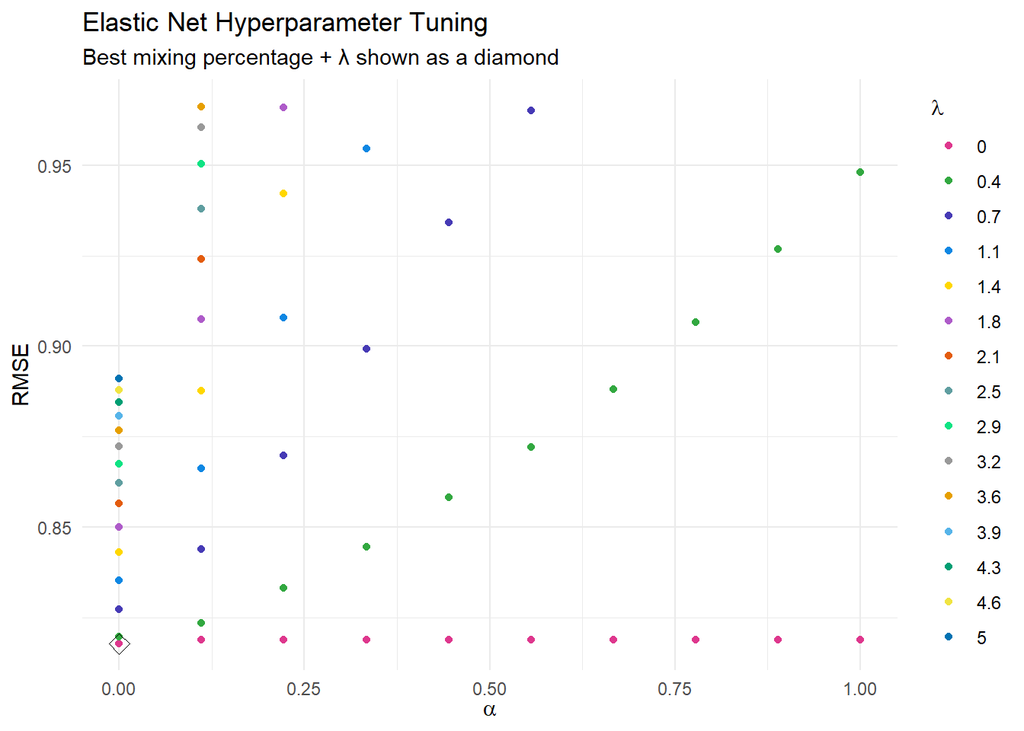

Figure 19. Hyperparamater Grid Search for Elastic Net

#### 6.2.3.3 Important Features

Important features can also be extracted, using the `varImp()` function from `caret`.

```r
important <- varImp(elasticMod)$importance
```

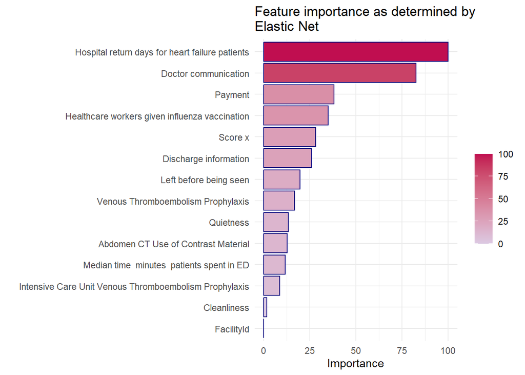

Figure 20. Variable Importance from Best Elastic Net Model

#### **Question 30**: [1 point]

Which of the features were most important? How does this compare to the most important features out of OLS regression? Make sure you’re looking at the **absolute value of the beta coefficients to assess importance in OLS regression**.

How about about of PCA? You may have already noticed that importance almost seems inverted! Why?!

**Hint 1**: What is the fundamental difference between a PCA and any regression?

**Hint 2**: What does “importance” mean in a PCA vs. any regression?

**Hint 3**: What does the sign of the loadings mean in a PCA? Are they actual or arbitrary?

> PCA and regression measure importance differently. PCA identifies variables that explain the most variation in the predictors, while regression identifies variables that best predict the outcome. Therefore, a variable can be important in PCA but not in regression, and vice versa. Additionally, the sign of PCA loadings is arbitrary, so only the magnitude reflects importance.

#### 6.2.3.2 Check model performance

Mean Absolute Error ($MAE$) is the average of the absolute differences between predicted and actual values, such that $MAE = \frac{1}{n}\sum_{i=1}^n\cdot|y_i-\hat{y}_i|$ where $y_i$ is each observed value, $\hat{y}_i$ is each corresponding predicted value, and $n$ is the number of observations. So, unlike $RMSE$, $MAE$ treats all errors equally and therefore is more robust to outliers. So, $MAE$ will tell you the average magnitude of the error, regardless of direction!

Let’s also make predictions on the testing sets for both the OLS and Elastic Net models using the `postResample()` function in `caret`; this will not only do predictions, but it will enable us to more easily generate metrics that we can use to compare model performance, such as $R^2$ and MAE.

```r
## Post-resample on OLS
prOLS <- postResample(pred = predict(bestMod, newdata = readyTest),
                      obs = readyTest$bc_PredictedReadmissionRate)

## Post-resample on Elastic Net
prElastic <- postResample(pred = predict(elasticMod, newdata = readyTest),
                      obs = readyTest$bc_PredictedReadmissionRate)
```

Table 12. Comparison of Model (Test) Performance of OLS and Elastic Net Regressions

|  | RMSE | Rsquared | MAE |
| --- | --- | --- | --- |
| prOLS | 0.84 | 0.31 | 0.67 |
| prElastic | 1.13 | NA | 0.90 |

#### 6.2.3.3 Check for overfitting/underfitting

Using the same method, check for overfitting / underfitting. Make predictions using `readyTrain` rather than `readyTest`, and then check how the $RMSE$ on the training data compares to the $RMSE$ of the training data for the Elastic Net. How do they compare? **How do both compare to what we got out of the OLS regression?**

```r
## Post-resample on OLS
prOLS <- postResample(pred = predict(bestMod, newdata = readyTrain),
                      obs = readyTrain$bc_PredictedReadmissionRate)

## Post-resample on Elastic Net
prElastic <- postResample(pred = predict(elasticMod, newdata = readyTrain),
                      obs = readyTrain$bc_PredictedReadmissionRate)
```

Table 13. Comparison of Training Performance of OLS and Elastic Net Regressions

|  | RMSE | Rsquared | MAE |
| --- | --- | --- | --- |
| prOLS | 0.8 | 0.32 | 0.64 |
| prElastic | 0.8 | 0.32 | 0.63 |

#### 6.2.3.4 Graphical comparison of the two models’ predictions

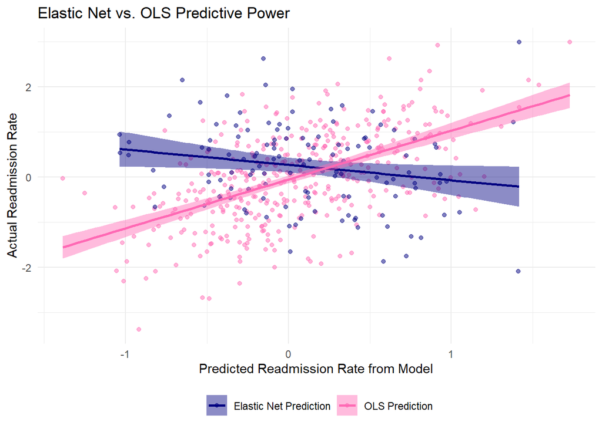

Figure 19. Predictions Plot for Elastic Net vs. OLS Regression

#### **Question 32**: [4 points]

What conclusions do you make at this point about whether to make predictions with an OLS regression, Elastic Net, or neither? What recommendations would you make to our client at this point? What other analyses might your suggest, or other data we might want to include? Please try to flesh out 2-3 recommendations in at least a paragraph.

**HINT**: Make sure to ask yourself whether these data appear linear or not. Could non-linearity be a cause for a low $R^2$? If not, what other causes are there and how will that impact your recommendations?

# 7 Choose Your Own Adventure

## Adventure 1.

**[Choosing one other condition to analyze.]**

- Make sure that you use the code I provided, updating it for your new condition
- Make sure to answer all of the interpretative questions again for your new dataset.
- I will specifically be looking for a comparison of which condition, pneumonia or the one you chose, seems to be a better choice for a predictive model for our client. Or is it neither?
- Make sure to include some next steps or recommendations based on your new analysis!

**Recommendations & Hints**:

You can avoid going back to Demo 1 to do your importing, cleaning, and pre-processing by running this source code:

```r
## Make any necessary changes in the R source code
## Uncomment to run!
# source(file = "reRunDemoData.R")
```

- Make sure to update your filepath to where you stored the hospital files on YOUR local machine, just as you did in Question 1 of the Demo!
- Make sure to update the condition that gets selected from “PN” to the condition of your choosing. A full list of available conditions is found in Demo 1.

## Adventure 2.

**[Choosing two or more conditions to analyze.]**

- Choose a slightly more complicated analysis to undertake, for example, focusing on surgical interventions (`HIP-KNEE` & `CABG`) or heart-related conditions (`HF`, `AMI`, & `CABG`).
- Make sure to note that the readmissions rates are **averages** across the total conditions you’ve selected!
- See the same recommendations and hints as Adventure 1.

## Adventure 3.

**[Continue analyzing the pneuomnia data.]**

- Make sure to justify your choice.
- Choose at least two new algorithms to perform. They can be unsupervised or supervised, but must be 2+.
- A natural extension would be to do a Ridge and/or a LASSO; the former would tell you if you should be controlling for multicollinearity more than you currently are, the latter would tell you if you need to further shrink coefficients than you currently are. Additionally, you could consider a regression-based method that incorporates **non-linearity**, such as a random forest. However, you are free to choose anything you think is appropriate here!
- Other choices I think you could potentially justify to stakeholders, if you were interested:
1. Switch to classification-based random forest using `ComparedToNational_Hospital return days for pneumonia patients`
2. kNN using the 2 clusters we’ve identified and named in our segmentation analysis
3. Our data are also ready for a neural network analysis (e.g., a feed-forward NN)!

## Deliverables

I am looking for 1-2 markdown documents with their knitted HTML. For example, if you’re choosing Adventures 1 or 2, you may want to work through this document once, make a copy of this markdown document, move the source code to the **TOP**, edit the source code as needed, and then go through this again from the beginning using the new condition(s) you chose.

Alternatively, if you’re choosing Adventure 3, maybe you just choose to add on to the bottom of this document, replacing the ‘Choose Your Own Adventure’ section with your actual adventure.

Just make sure to answer the questions well,and make sure to justify the decisions you make. Tell me WHY you’re choosing the condition(s) you are in Adventures 1 or 2, or Tell me WHY you’re doing the analyses you are in Adventure 3. Other than that, make this your own learning adventure!

# References

Box, G. E. P., and D. R. Cox. 2018. “An Analysis of Transformations.” *Journal of the Royal Statistical Society: Series B (Methodological)* 26 (2): 211–43. https://doi.org/10.1111/j.2517-6161.1964.tb00553.x.

De Alba, Israel, and Alpesh Amin. 2014. “Pneumonia Readmissions: Risk Factors and Implications.” *Ochsner Journal* 14 (4): 649–54.

R Core Team. 2019. *R: A Language and Environment for Statistical Computing*. Vienna, Austria: R Foundation for Statistical Computing. https://www.R-project.org.

Yeo, In‐Kwon, and Richard A. Johnson. 2000. “A New Family of Power Transformations to Improve Normality or Symmetry.” *Biometrika* 87 (4): 954–59. https://doi.org/10.1093/biomet/87.4.954.

Zou, Hui, and Trevor Hastie. 2005. “Regularization and Variable Selection via the Elastic Net.” *Journal of the Royal Statistical Society Series B: Statistical Methodology* 67 (2): 301–20. https://doi.org/10.1111/j.1467-9868.2005.00503.x.